# GAMM summaries and diagnostics for Diphthong Dynamics under Lexical Tone: Cross-Dialectal Evidence for Category-Specific f0–F1 Coupling

## 1.10 XA_f0_2Diph_NoAsp_Overall_baseline_notZ

```r
XA_f0_2Diph_NoAsp_Overall_baseline_notZ_AR1 <- readRDS("XA_f0_2Diph_NoAsp_Overall_baseline_notZ_AR1.rds")
```

```r
summary(XA_f0_2Diph_NoAsp_Overall_baseline_notZ_AR1, re.test = FALSE)
```

```
Family: gaussian
Link function: identity

Formula:
f0_10C ~ ToneVarDiphInt.ord + order.ord + sex.ord + leftSegment.ord +
    type.ord + s(measurement.no, bs = "cr", k = 11, m = 1) +
    s(measurement.no, by = ToneVarDiphInt.ord, bs = "cr", k = 11,
        m = 1) + s(measurement.no, by = order.ord, bs = "cr",
    k = 11, m = 1) + s(measurement.no, by = sex.ord, bs = "cr",
    k = 11, m = 1) + s(measurement.no, by = leftSegment.ord,
    bs = "cr", k = 11, m = 1) + s(measurement.no, by = type.ord,
    bs = "cr", k = 11, m = 1) + s(measurement.no, speaker, bs = "fs",
    xt = list(bs = "tp"), k = 11, m = 1) + s(measurement.no,
    speaker, bs = "fs", xt = list(bs = "tp"), k = 11, m = 1,
    by = ToneVarDiphInt.ord) + s(measurement.no, character, bs = "fs",
    xt = list(bs = "tp"), k = 11, m = 1) + s(measurement.no,
    character, bs = "fs", xt = list(bs = "tp"), k = 11, m = 1,
    by = sex.ord) + s(measurement.no, character, bs = "fs", xt = list(bs = "tp"),
    k = 11, m = 1, by = order.ord) + s(measurement.no, character,
    bs = "fs", xt = list(bs = "tp"), k = 11, m = 1, by = type.ord) +
    s(measurement.no, character, bs = "fs", xt = list(bs = "tp"),
        k = 11, m = 1, by = variety.ord)

Parametric coefficients:
                          Estimate Std. Error t value Pr(>|t|)
(Intercept)                3.34551    0.25234  13.258  < 2e-16 ***
ToneVarDiphInt.ord1 SM aw  0.22734    0.28361   0.802 0.422800
ToneVarDiphInt.ord1 XA aj -7.64207    0.34937 -21.874  < 2e-16 ***
ToneVarDiphInt.ord1 XA aw -7.19728    0.38536 -18.677  < 2e-16 ***
ToneVarDiphInt.ord2 SM aj -5.29226    0.35046 -15.101  < 2e-16 ***
ToneVarDiphInt.ord2 SM aw -5.01767    0.31607 -15.875  < 2e-16 ***
ToneVarDiphInt.ord2 XA aj -5.07496    0.38698 -13.114  < 2e-16 ***
ToneVarDiphInt.ord2 XA aw -4.98622    0.31663 -15.748  < 2e-16 ***
ToneVarDiphInt.ord3 SM aj -8.34009    0.49417 -16.877  < 2e-16 ***
ToneVarDiphInt.ord3 SM aw -8.46543    0.40240 -21.037  < 2e-16 ***
ToneVarDiphInt.ord3 XA aj -3.95582    0.36540 -10.826  < 2e-16 ***
ToneVarDiphInt.ord3 XA aw -4.27561    0.37790 -11.314  < 2e-16 ***
ToneVarDiphInt.ord4 SM aj -3.37196    0.24833 -13.579  < 2e-16 ***
ToneVarDiphInt.ord4 SM aw -2.88528    0.34236  -8.428  < 2e-16 ***
ToneVarDiphInt.ord4 XA aj -0.99947    0.26075  -3.833 0.000127 ***
```

[output cut: 24 more lines]

```
s(measurement.no):ToneVarDiphInt.ord4 SM aj 7.836  8.116 45.947  < 2e-16 ***
s(measurement.no):ToneVarDiphInt.ord4 SM aw 7.721  8.072 46.448  < 2e-16 ***
s(measurement.no):ToneVarDiphInt.ord4 XA aj 2.031  2.426  1.623  0.22810
s(measurement.no):ToneVarDiphInt.ord4 XA aw 2.820  3.350  2.083  0.08841 .
s(measurement.no):order.ordX                1.016  1.023  3.147  0.07340 .
s(measurement.no):sex.ordM                  5.349  6.052 13.207  < 2e-16 ***
s(measurement.no):leftSegment.ordn          1.001  1.002  7.893  0.00495 **
s(measurement.no):leftSegment.ordp          3.936  4.754  2.663  0.02224 *
s(measurement.no):leftSegment.ordt          6.791  7.775  5.490  < 2e-16 ***
s(measurement.no):type.ord2                 4.228  5.064  6.898 2.21e-06 ***
---
Signif. codes:  0 ‘***’ 0.001 ‘**’ 0.01 ‘*’ 0.05 ‘.’ 0.1 ‘ ’ 1

R-sq.(adj) =  0.835   Deviance explained = 85.2%
fREML =  30205  Scale est. = 1.2926    n = 23087
```

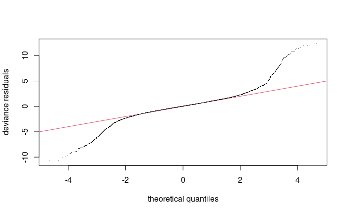

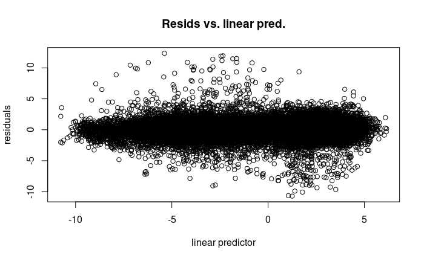

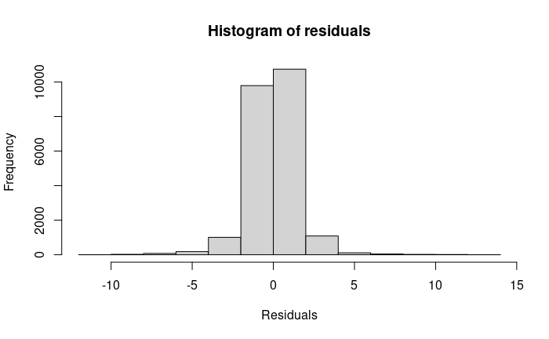

[output not shown]

[output cut: 137 more lines]

```
s(measurement.no,speaker):ToneVarDiphInt.ord2 XA aj 264.00  87.15    1.03    0.98
s(measurement.no,speaker):ToneVarDiphInt.ord2 XA aw 264.00 112.86    1.03    0.98
s(measurement.no,speaker):ToneVarDiphInt.ord3 SM aj 264.00 178.18    1.03    0.98
s(measurement.no,speaker):ToneVarDiphInt.ord3 SM aw 264.00 175.97    1.03    0.97
s(measurement.no,speaker):ToneVarDiphInt.ord3 XA aj 264.00 187.66    1.03    0.99
s(measurement.no,speaker):ToneVarDiphInt.ord3 XA aw 264.00 184.13    1.03    0.97
s(measurement.no,speaker):ToneVarDiphInt.ord4 SM aj 264.00 203.73    1.03    0.98
s(measurement.no,speaker):ToneVarDiphInt.ord4 SM aw 264.00 194.57    1.03    0.99
s(measurement.no,speaker):ToneVarDiphInt.ord4 XA aj 264.00  19.50    1.03    0.96
s(measurement.no,speaker):ToneVarDiphInt.ord4 XA aw 264.00  19.11    1.03    0.99
s(measurement.no,character)                         352.00  36.66    1.03    1.00
s(measurement.no,character):sex.ordM                352.00  64.59    1.03    0.98
s(measurement.no,character):order.ordX              352.00  29.70    1.03    0.98
s(measurement.no,character):type.ord2               352.00 148.86    1.03    0.98
s(measurement.no,character):variety.ordXA           352.00  76.14    1.03    0.99
```

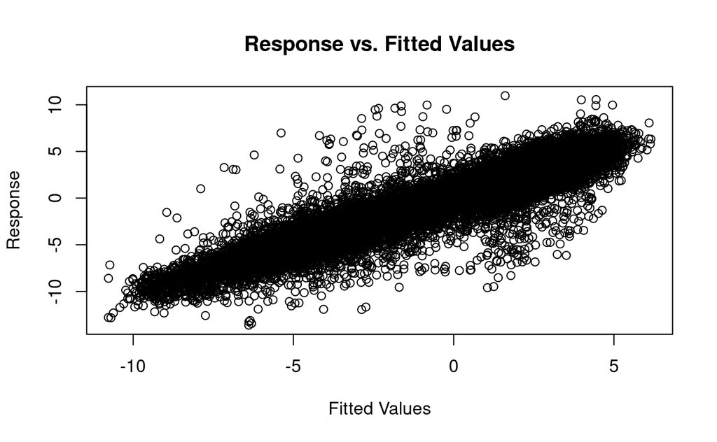

```r
gam.check(XA_f0_2Diph_NoAsp_Overall_baseline_notZ_AR1)
```

## 1.11 TJ_f0_2Diph_NoAsp_Overall_baseline_notZ

```r
TJ_f0_2Diph_NoAsp_Overall_baseline_notZ_AR1 <- readRDS("TJ_f0_2Diph_NoAsp_Overall_baseline_notZ_AR1.rds")
```

```r
summary(TJ_f0_2Diph_NoAsp_Overall_baseline_notZ_AR1, re.test = FALSE)
```

```
Family: gaussian
Link function: identity

Formula:
f0_10C ~ ToneVarDiphInt.ord + order.ord + sex.ord + leftSegment.ord +
    type.ord + s(measurement.no, bs = "cr", k = 11, m = 1) +
    s(measurement.no, by = ToneVarDiphInt.ord, bs = "cr", k = 11,
        m = 1) + s(measurement.no, by = order.ord, bs = "cr",
    k = 11, m = 1) + s(measurement.no, by = sex.ord, bs = "cr",
    k = 11, m = 1) + s(measurement.no, by = leftSegment.ord,
    bs = "cr", k = 11, m = 1) + s(measurement.no, by = type.ord,
    bs = "cr", k = 11, m = 1) + s(measurement.no, speaker, bs = "fs",
    xt = list(bs = "tp"), k = 11, m = 1) + s(measurement.no,
    speaker, bs = "fs", xt = list(bs = "tp"), k = 11, m = 1,
    by = ToneVarDiphInt.ord) + s(measurement.no, character, bs = "fs",
    xt = list(bs = "tp"), k = 11, m = 1) + s(measurement.no,
    character, bs = "fs", xt = list(bs = "tp"), k = 11, m = 1,
    by = sex.ord) + s(measurement.no, character, bs = "fs", xt = list(bs = "tp"),
    k = 11, m = 1, by = order.ord) + s(measurement.no, character,
    bs = "fs", xt = list(bs = "tp"), k = 11, m = 1, by = type.ord) +
    s(measurement.no, character, bs = "fs", xt = list(bs = "tp"),
        k = 11, m = 1, by = variety.ord)

Parametric coefficients:
                          Estimate Std. Error t value Pr(>|t|)
(Intercept)                4.11629    0.46032   8.942  < 2e-16 ***
ToneVarDiphInt.ord1 SM aw  0.40506    0.26076   1.553   0.1203
ToneVarDiphInt.ord1 TJ aj -6.28776    0.47393 -13.267  < 2e-16 ***
ToneVarDiphInt.ord1 TJ aw -5.82267    0.52261 -11.142  < 2e-16 ***
ToneVarDiphInt.ord2 SM aj -4.41872    0.38816 -11.384  < 2e-16 ***
ToneVarDiphInt.ord2 SM aw -3.83195    0.35559 -10.776  < 2e-16 ***
ToneVarDiphInt.ord2 TJ aj -3.50911    0.53474  -6.562 5.43e-11 ***
ToneVarDiphInt.ord2 TJ aw -2.81317    0.61532  -4.572 4.86e-06 ***
ToneVarDiphInt.ord3 SM aj -8.26255    0.49718 -16.619  < 2e-16 ***
ToneVarDiphInt.ord3 SM aw -8.00597    0.57057 -14.031  < 2e-16 ***
ToneVarDiphInt.ord3 TJ aj -7.79150    0.51520 -15.123  < 2e-16 ***
ToneVarDiphInt.ord3 TJ aw -7.60271    0.52369 -14.518  < 2e-16 ***
ToneVarDiphInt.ord4 SM aj -2.64960    0.24689 -10.732  < 2e-16 ***
ToneVarDiphInt.ord4 SM aw -2.49194    0.32623  -7.638 2.29e-14 ***
ToneVarDiphInt.ord4 TJ aj -2.29676    0.53850  -4.265 2.01e-05 ***
```

[output cut: 24 more lines]

```
s(measurement.no):ToneVarDiphInt.ord4 SM aj 8.101  8.483 64.252  < 2e-16 ***
s(measurement.no):ToneVarDiphInt.ord4 SM aw 8.057  8.433 53.582  < 2e-16 ***
s(measurement.no):ToneVarDiphInt.ord4 TJ aj 7.912  8.340 52.693  < 2e-16 ***
s(measurement.no):ToneVarDiphInt.ord4 TJ aw 7.744  8.162 35.187  < 2e-16 ***
s(measurement.no):order.ordT                1.001  1.001  0.417  0.51862
s(measurement.no):sex.ordM                  3.373  3.686  4.312  0.00274 **
s(measurement.no):leftSegment.ordn          1.372  1.570  0.360  0.76123
s(measurement.no):leftSegment.ordp          3.961  4.826  5.624 7.92e-05 ***
s(measurement.no):leftSegment.ordt          6.454  7.543  4.830 1.83e-05 ***
s(measurement.no):type.ord2                 5.051  6.171  3.357  0.00239 **
---
Signif. codes:  0 ‘***’ 0.001 ‘**’ 0.01 ‘*’ 0.05 ‘.’ 0.1 ‘ ’ 1

R-sq.(adj) =  0.812   Deviance explained = 83.5%
fREML =  34032  Scale est. = 1.8764    n = 23230
```

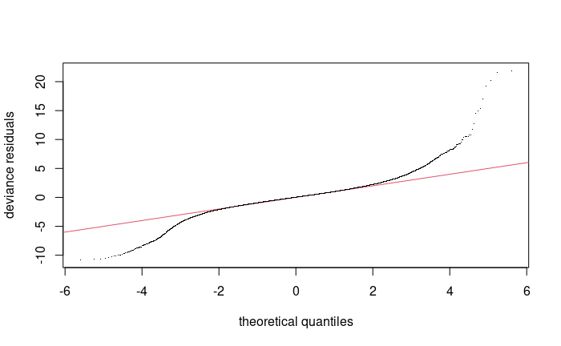

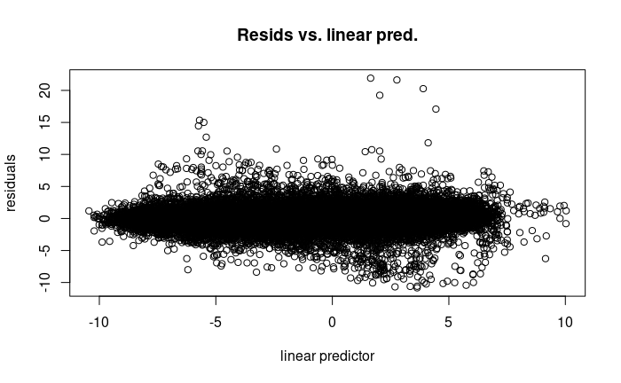

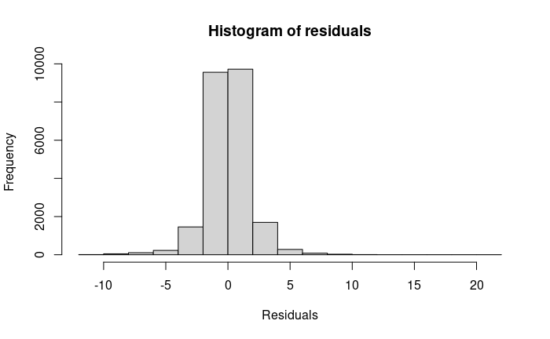

[output not shown]

[output cut: 137 more lines]

```
s(measurement.no,speaker):ToneVarDiphInt.ord2 TJ aj 264.00  87.11    1.01    0.71
s(measurement.no,speaker):ToneVarDiphInt.ord2 TJ aw 264.00 131.01    1.01    0.67
s(measurement.no,speaker):ToneVarDiphInt.ord3 SM aj 264.00 151.26    1.01    0.71
s(measurement.no,speaker):ToneVarDiphInt.ord3 SM aw 264.00 171.86    1.01    0.68
s(measurement.no,speaker):ToneVarDiphInt.ord3 TJ aj 264.00 161.14    1.01    0.69
s(measurement.no,speaker):ToneVarDiphInt.ord3 TJ aw 264.00 206.05    1.01    0.68
s(measurement.no,speaker):ToneVarDiphInt.ord4 SM aj 264.00 168.08    1.01    0.65
s(measurement.no,speaker):ToneVarDiphInt.ord4 SM aw 264.00 178.80    1.01    0.78
s(measurement.no,speaker):ToneVarDiphInt.ord4 TJ aj 264.00 170.02    1.01    0.71
s(measurement.no,speaker):ToneVarDiphInt.ord4 TJ aw 264.00 176.12    1.01    0.65
s(measurement.no,character)                         330.00  11.72    1.01    0.59
s(measurement.no,character):sex.ordM                330.00  98.39    1.01    0.72
s(measurement.no,character):order.ordT              330.00  63.58    1.01    0.64
s(measurement.no,character):type.ord2               330.00 109.06    1.01    0.69
s(measurement.no,character):variety.ordTJ           330.00  32.43    1.01    0.66
```

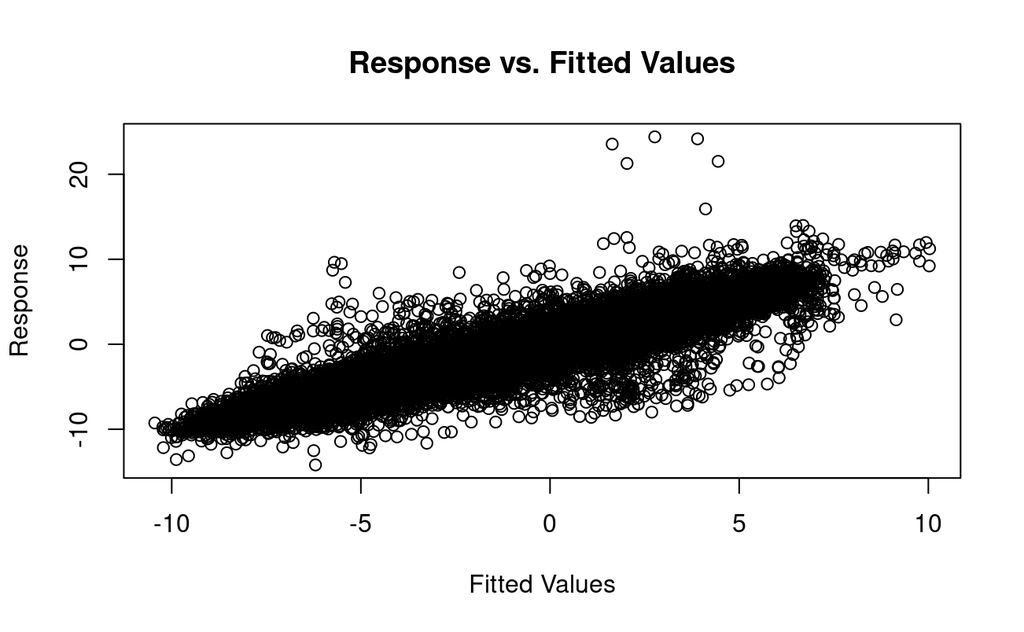

```r
gam.check(TJ_f0_2Diph_NoAsp_Overall_baseline_notZ_AR1)
```

## 1.12 XA_F1_f0_Optimized_notZ

```r
XA_F1_f0_Optimized_notZ_AR1 <- readRDS("XA_F1_f0_Optimized_notZ_AR1.rds")
```

```r
summary(XA_F1_f0_Optimized_notZ_AR1, re.test = FALSE)
```

```
Family: gaussian
Link function: identity

Formula:
f1C ~ DiphVar.ord + sex.ord + type.ord + order.ord + leftSegment.ord +
    s(measurement.no, bs = "cr", k = 11, m = 1) + s(f0_10C, bs = "cr",
    k = 11, m = 1) + s(durationZ, bs = "cr", k = 11, m = 1) +
    ti(measurement.no, f0_10C, k = c(11, 11)) + ti(measurement.no,
    durationZ, k = c(11, 11)) + ti(f0_10C, durationZ, k = c(11,
    11)) + ti(measurement.no, durationZ, f0_10C, k = c(11, 11,
    11)) + ti(measurement.no, f0_10C, by = DiphVar.ord, k = c(11,
    11)) + ti(measurement.no, f0_10C, by = sex.ord, k = c(11,
    11)) + s(measurement.no, by = DiphVar.ord, bs = "cr", k = 11,
    m = 1) + s(measurement.no, by = type.ord, bs = "cr", k = 11,
    m = 1) + s(measurement.no, by = order.ord, bs = "cr", k = 11,
    m = 1) + s(measurement.no, by = sex.ord, bs = "cr", k = 11,
    m = 1) + s(measurement.no, by = leftSegment.ord, bs = "cr",
    k = 11, m = 1) + s(f0_10C, by = DiphVar.ord, bs = "cr", k = 11,
    m = 1) + s(f0_10C, by = sex.ord, bs = "cr", k = 11, m = 1) +
    s(measurement.no, speaker, bs = "fs", xt = list(bs = "tp"),
        k = 11, m = 1) + s(measurement.no, speaker, bs = "fs",
    xt = list(bs = "tp"), k = 11, m = 1, by = DiphVar.ord) +
    s(measurement.no, character, bs = "fs", xt = list(bs = "tp"),
        k = 11, m = 1) + s(f0_10C, speaker, bs = "fs", xt = list(bs = "tp"),
    k = 11, m = 1) + s(f0_10C, character, bs = "fs", xt = list(bs = "tp"),
    k = 11, m = 1) + s(durationZ, speaker, bs = "fs", xt = list(bs = "tp"),
    k = 11, m = 1)

Parametric coefficients:
                  Estimate Std. Error t value Pr(>|t|)
(Intercept)       0.458795   0.073556   6.237 4.53e-10 ***
DiphVar.ordaj XA -0.393176   0.061954  -6.346 2.25e-10 ***
DiphVar.ordaw SM -0.349595   0.072597  -4.816 1.48e-06 ***
DiphVar.ordaw XA -0.626852   0.081636  -7.679 1.67e-14 ***
sex.ordM         -0.158658   0.056016  -2.832  0.00462 **
type.ord2         0.148276   0.009098  16.297  < 2e-16 ***
order.ordX        0.066876   0.055583   1.203  0.22892
leftSegment.ordn  0.028064   0.070112   0.400  0.68896
leftSegment.ordp -0.137331   0.064611  -2.126  0.03356 *
leftSegment.ordt -0.146169   0.073229  -1.996  0.04594 *
```

[output cut: 19 more lines]

```
s(measurement.no):type.ord2                 5.169  6.579  49.411  < 2e-16 ***
s(measurement.no):order.ordX                1.001  1.001   0.631 0.427066
s(measurement.no):sex.ordM                  6.703  6.929  18.504  < 2e-16 ***
s(measurement.no):leftSegment.ordn          8.321  8.903  11.283  < 2e-16 ***
s(measurement.no):leftSegment.ordp          7.733  8.473   5.843  < 2e-16 ***
s(measurement.no):leftSegment.ordt          4.489  5.179   3.144 0.009465 **
s(f0_10C):DiphVar.ordaj XA                  2.286  2.849   1.894 0.138985
s(f0_10C):DiphVar.ordaw SM                  3.161  3.807   1.570 0.173858
s(f0_10C):DiphVar.ordaw XA                  3.725  4.503   2.301 0.038444 *
s(f0_10C):sex.ordM                          1.000  1.001   4.055 0.044038 *
---
Signif. codes:  0 ‘***’ 0.001 ‘**’ 0.01 ‘*’ 0.05 ‘.’ 0.1 ‘ ’ 1

R-sq.(adj) =  0.778   Deviance explained = 79.1%
fREML = 8534.4  Scale est. = 0.1452    n = 23087
```

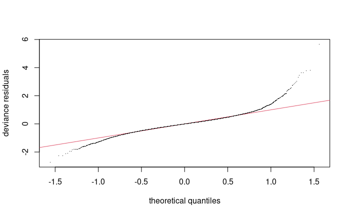

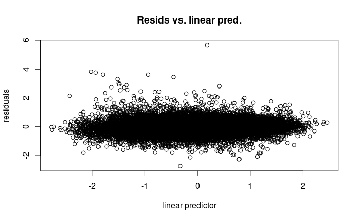

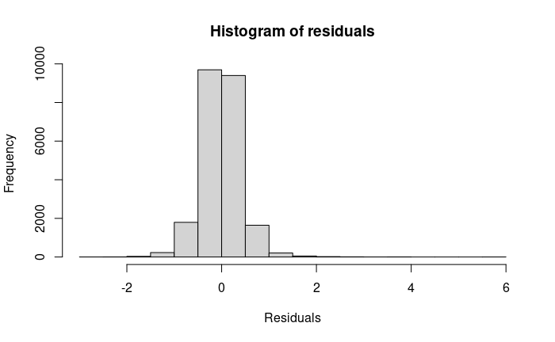

[output not shown]

[output cut: 124 more lines]

```
s(measurement.no):leftSegment.ordt           10.00    4.49    1.02    0.89
s(f0_10C):DiphVar.ordaj XA                   10.00    2.29    0.99    0.32
s(f0_10C):DiphVar.ordaw SM                   10.00    3.16    0.99    0.28
s(f0_10C):DiphVar.ordaw XA                   10.00    3.72    0.99    0.29
s(f0_10C):sex.ordM                           10.00    1.00    0.99    0.26
s(measurement.no,speaker)                   264.00  190.04    1.02    0.85
s(measurement.no,speaker):DiphVar.ordaj XA  264.00  112.14    1.02    0.83
s(measurement.no,speaker):DiphVar.ordaw SM  264.00  109.94    1.02    0.91
s(measurement.no,speaker):DiphVar.ordaw XA  264.00  102.58    1.02    0.86
s(measurement.no,character)                 352.00  136.99    1.02    0.85
s(f0_10C,speaker)                           264.00  118.51    0.99    0.28
s(f0_10C,character)                         352.00  122.54    0.99    0.32
s(durationZ,speaker)                        264.00  105.33    0.80  <2e-16 ***
---
Signif. codes:  0 ‘***’ 0.001 ‘**’ 0.01 ‘*’ 0.05 ‘.’ 0.1 ‘ ’ 1
```

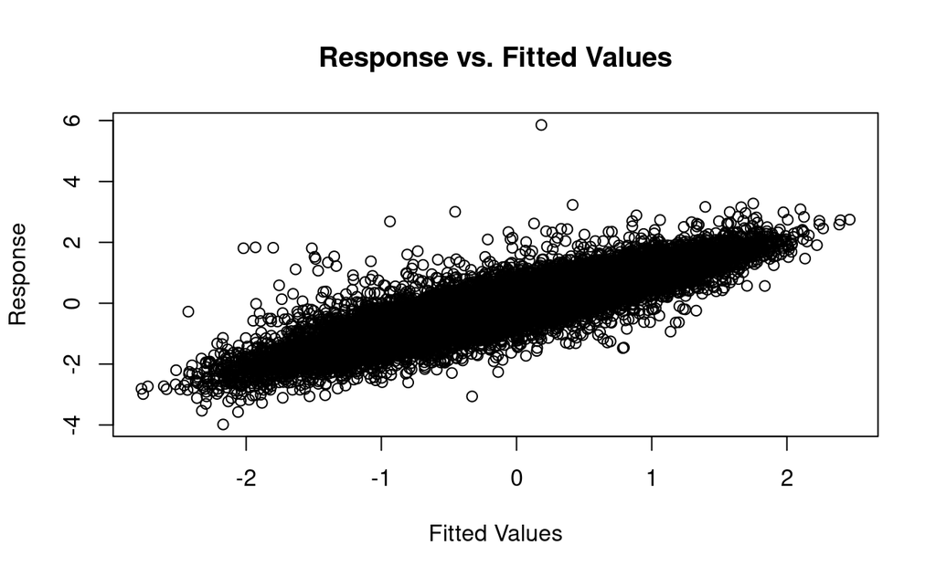

```r
gam.check(XA_F1_f0_Optimized_notZ_AR1)
```

## 1.13 TJ_F1_f0_Optimized_notZ

```r
TJ_F1_f0_Optimized_notZ_AR1 <- readRDS("TJ_F1_f0_Optimized_notZ_AR1.rds")
```

```r
summary(TJ_F1_f0_Optimized_notZ_AR1, re.test = FALSE)
```

```
Family: gaussian
Link function: identity

Formula:
f1C ~ DiphVar.ord + sex.ord + type.ord + order.ord + leftSegment.ord +
    s(measurement.no, bs = "cr", k = 11, m = 1) + s(f0_10C, bs = "cr",
    k = 11, m = 1) + s(durationZ, bs = "cr", k = 11, m = 1) +
    ti(measurement.no, f0_10C, k = c(11, 11)) + ti(measurement.no,
    durationZ, k = c(11, 11)) + ti(f0_10C, durationZ, k = c(11,
    11)) + ti(measurement.no, durationZ, f0_10C, k = c(11, 11,
    11)) + ti(measurement.no, f0_10C, by = DiphVar.ord, k = c(11,
    11)) + ti(measurement.no, f0_10C, by = sex.ord, k = c(11,
    11)) + s(measurement.no, by = DiphVar.ord, bs = "cr", k = 11,
    m = 1) + s(measurement.no, by = type.ord, bs = "cr", k = 11,
    m = 1) + s(measurement.no, by = order.ord, bs = "cr", k = 11,
    m = 1) + s(measurement.no, by = sex.ord, bs = "cr", k = 11,
    m = 1) + s(measurement.no, by = leftSegment.ord, bs = "cr",
    k = 11, m = 1) + s(f0_10C, by = DiphVar.ord, bs = "cr", k = 11,
    m = 1) + s(f0_10C, by = sex.ord, bs = "cr", k = 11, m = 1) +
    s(measurement.no, speaker, bs = "fs", xt = list(bs = "tp"),
        k = 11, m = 1) + s(measurement.no, speaker, bs = "fs",
    xt = list(bs = "tp"), k = 11, m = 1, by = DiphVar.ord) +
    s(measurement.no, character, bs = "fs", xt = list(bs = "tp"),
        k = 11, m = 1) + s(f0_10C, speaker, bs = "fs", xt = list(bs = "tp"),
    k = 11, m = 1) + s(f0_10C, character, bs = "fs", xt = list(bs = "tp"),
    k = 11, m = 1) + s(durationZ, speaker, bs = "fs", xt = list(bs = "tp"),
    k = 11, m = 1)

Parametric coefficients:
                  Estimate Std. Error t value Pr(>|t|)
(Intercept)       0.329284   0.054113   6.085 1.18e-09 ***
DiphVar.ordaj TJ  0.042836   0.039657   1.080  0.28007
DiphVar.ordaw SM -0.378358   0.045564  -8.304  < 2e-16 ***
DiphVar.ordaw TJ -0.367817   0.051556  -7.134 1.00e-12 ***
sex.ordM         -0.130409   0.050550  -2.580  0.00989 **
type.ord2         0.067472   0.008712   7.745 9.96e-15 ***
order.ordT       -0.036859   0.050321  -0.732  0.46389
leftSegment.ordn  0.035864   0.040632   0.883  0.37743
leftSegment.ordp -0.198689   0.036588  -5.430 5.68e-08 ***
leftSegment.ordt -0.092178   0.040565  -2.272  0.02307 *
```

[output cut: 19 more lines]

```
s(measurement.no):type.ord2                 7.998   9.250  54.569  < 2e-16 ***
s(measurement.no):order.ordT                2.097   2.160   2.294  0.10442
s(measurement.no):sex.ordM                  3.838   3.981   4.562  0.00134 **
s(measurement.no):leftSegment.ordn          7.341   8.314   8.466  < 2e-16 ***
s(measurement.no):leftSegment.ordp          7.077   8.092   4.431 3.63e-05 ***
s(measurement.no):leftSegment.ordt          5.345   6.350   6.320 2.04e-07 ***
s(f0_10C):DiphVar.ordaj TJ                  1.000   1.001   1.017  0.31328
s(f0_10C):DiphVar.ordaw SM                  1.001   1.001   2.511  0.11294
s(f0_10C):DiphVar.ordaw TJ                  1.000   1.001   7.025  0.00804 **
s(f0_10C):sex.ordM                          1.004   1.005   1.508  0.22036
---
Signif. codes:  0 ‘***’ 0.001 ‘**’ 0.01 ‘*’ 0.05 ‘.’ 0.1 ‘ ’ 1

R-sq.(adj) =  0.836   Deviance explained = 84.5%
fREML =  10607  Scale est. = 0.16123   n = 23230
```

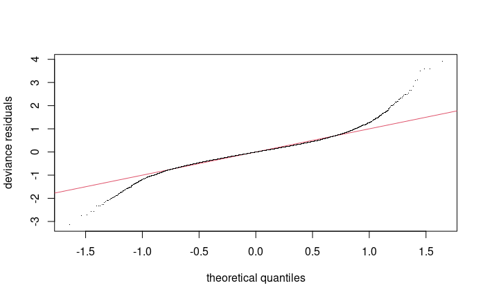

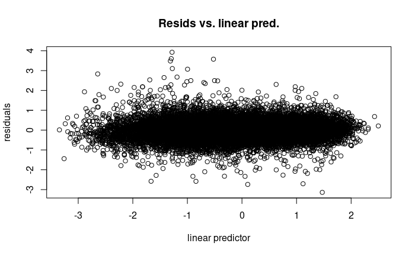

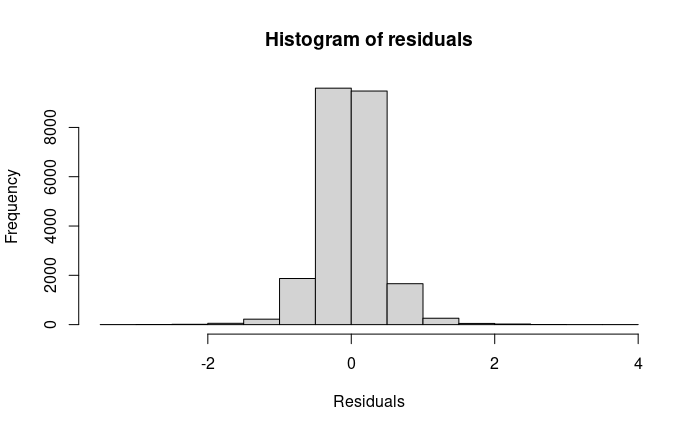

[output not shown]

[output cut: 124 more lines]

```
s(measurement.no):leftSegment.ordt           10.00    5.34    1.01   0.725
s(f0_10C):DiphVar.ordaj TJ                   10.00    1.00    1.00   0.485
s(f0_10C):DiphVar.ordaw SM                   10.00    1.00    1.00   0.480
s(f0_10C):DiphVar.ordaw TJ                   10.00    1.00    1.00   0.490
s(f0_10C):sex.ordM                           10.00    1.00    1.00   0.465
s(measurement.no,speaker)                   264.00  196.06    1.01   0.720
s(measurement.no,speaker):DiphVar.ordaj TJ  264.00  110.16    1.01   0.775
s(measurement.no,speaker):DiphVar.ordaw SM  264.00  144.62    1.01   0.690
s(measurement.no,speaker):DiphVar.ordaw TJ  264.00  157.83    1.01   0.725
s(measurement.no,character)                 330.00   92.63    1.01   0.700
s(f0_10C,speaker)                           264.00  110.15    1.00   0.440
s(f0_10C,character)                         330.00   63.57    1.00   0.530
s(durationZ,speaker)                        264.00  100.28    0.87  <2e-16 ***
---
Signif. codes:  0 ‘***’ 0.001 ‘**’ 0.01 ‘*’ 0.05 ‘.’ 0.1 ‘ ’ 1
```

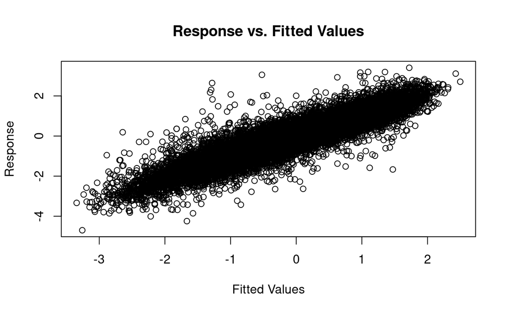

```r
gam.check(TJ_F1_f0_Optimized_notZ_AR1)
```

# 2 Model comparisons

## 2.1 XA model F1

### 2.1.1 Random effects

```r
XA_F1_2Diph_NoAsp_Overall_baseline_1.noAR <- readRDS("XA_F1_2Diph_NoAsp_Overall_baseline_1_noAR.rds")
XA_F1_2Diph_NoAsp_Overall_baseline_2.noAR <- readRDS("XA_F1_2Diph_NoAsp_Overall_baseline_2_noAR.rds")
XA_F1_2Diph_NoAsp_Overall_baseline.noAR <- readRDS("XA_F1_2Diph_NoAsp_Overall_baseline_noAR.rds")
```

XA_F1_2Diph_NoAsp_Overall_baseline_1.noAR: no random effects

XA_F1_2Diph_NoAsp_Overall_baseline_2.noAR: + speaker random factor smooths

```r
compareML(XA_F1_2Diph_NoAsp_Overall_baseline_1.noAR,XA_F1_2Diph_NoAsp_Overall_baseline_2.noAR)
```

```
XA_F1_2Diph_NoAsp_Overall_baseline_1.noAR: f1Z ~ ToneVarDiphInt.ord + order.ord + sex.ord + leftSegment.ord +
    type.ord + s(measurement.no, bs = "cr", k = 11, m = 1) +
    s(measurement.no, by = ToneVarDiphInt.ord, bs = "cr", k = 11,
        m = 1) + s(measurement.no, by = order.ord, bs = "cr",
    k = 11, m = 1) + s(measurement.no, by = sex.ord, bs = "cr",
    k = 11, m = 1) + s(measurement.no, by = leftSegment.ord,
    bs = "cr", k = 11, m = 1) + s(measurement.no, by = type.ord,
    bs = "cr", k = 11, m = 1)

XA_F1_2Diph_NoAsp_Overall_baseline_2.noAR: f1Z ~ ToneVarDiphInt.ord + order.ord + sex.ord + leftSegment.ord +
    type.ord + s(measurement.no, bs = "cr", k = 11, m = 1) +
    s(measurement.no, by = ToneVarDiphInt.ord, bs = "cr", k = 11,
        m = 1) + s(measurement.no, by = order.ord, bs = "cr",
    k = 11, m = 1) + s(measurement.no, by = sex.ord, bs = "cr",
    k = 11, m = 1) + s(measurement.no, by = leftSegment.ord,
    bs = "cr", k = 11, m = 1) + s(measurement.no, by = type.ord,
    bs = "cr", k = 11, m = 1) + s(measurement.no, speaker, bs = "fs",
    xt = list(bs = "tp"), k = 11, m = 1) + s(measurement.no,
    speaker, bs = "fs", xt = list(bs = "tp"), k = 11, m = 1,
    by = ToneVarDiphInt.ord)

Chi-square test of fREML scores
-----
                                      Model    Score Edf Difference     Df  p.value Sig.
1 XA_F1_2Diph_NoAsp_Overall_baseline_1.noAR 26651.71  22
2 XA_F1_2Diph_NoAsp_Overall_baseline_2.noAR 22053.64  54   4598.063 32.000  < 2e-16  ***

AIC difference: 10816.72, model XA_F1_2Diph_NoAsp_Overall_baseline_2.noAR has lower AIC.
```

XA_F1_2Diph_NoAsp_Overall_baseline.noAR: + character random factor smooths

```r
compareML(XA_F1_2Diph_NoAsp_Overall_baseline_2.noAR,XA_F1_2Diph_NoAsp_Overall_baseline.noAR)
```

```
XA_F1_2Diph_NoAsp_Overall_baseline_2.noAR: f1Z ~ ToneVarDiphInt.ord + order.ord + sex.ord + leftSegment.ord +
    type.ord + s(measurement.no, bs = "cr", k = 11, m = 1) +
    s(measurement.no, by = ToneVarDiphInt.ord, bs = "cr", k = 11,
        m = 1) + s(measurement.no, by = order.ord, bs = "cr",
    k = 11, m = 1) + s(measurement.no, by = sex.ord, bs = "cr",
    k = 11, m = 1) + s(measurement.no, by = leftSegment.ord,
    bs = "cr", k = 11, m = 1) + s(measurement.no, by = type.ord,
    bs = "cr", k = 11, m = 1) + s(measurement.no, speaker, bs = "fs",
    xt = list(bs = "tp"), k = 11, m = 1) + s(measurement.no,
    speaker, bs = "fs", xt = list(bs = "tp"), k = 11, m = 1,
    by = ToneVarDiphInt.ord)

XA_F1_2Diph_NoAsp_Overall_baseline.noAR: f1Z ~ ToneVarDiphInt.ord + order.ord + sex.ord + leftSegment.ord +
    type.ord + s(measurement.no, bs = "cr", k = 11, m = 1) +
    s(measurement.no, by = ToneVarDiphInt.ord, bs = "cr", k = 11,
        m = 1) + s(measurement.no, by = order.ord, bs = "cr",
    k = 11, m = 1) + s(measurement.no, by = sex.ord, bs = "cr",
    k = 11, m = 1) + s(measurement.no, by = leftSegment.ord,
    bs = "cr", k = 11, m = 1) + s(measurement.no, by = type.ord,
    bs = "cr", k = 11, m = 1) + s(measurement.no, speaker, bs = "fs",
    xt = list(bs = "tp"), k = 11, m = 1) + s(measurement.no,
    speaker, bs = "fs", xt = list(bs = "tp"), k = 11, m = 1,
    by = ToneVarDiphInt.ord) + s(measurement.no, character, bs = "fs",
    xt = list(bs = "tp"), k = 11, m = 1) + s(measurement.no,
    character, bs = "fs", xt = list(bs = "tp"), k = 11, m = 1,
    by = sex.ord) + s(measurement.no, character, bs = "fs", xt = list(bs = "tp"),
    k = 11, m = 1, by = order.ord) + s(measurement.no, character,
    bs = "fs", xt = list(bs = "tp"), k = 11, m = 1, by = type.ord) +
    s(measurement.no, character, bs = "fs", xt = list(bs = "tp"),
        k = 11, m = 1, by = variety.ord)

Chi-square test of fREML scores
-----
                                      Model    Score Edf Difference     Df  p.value Sig.
1 XA_F1_2Diph_NoAsp_Overall_baseline_2.noAR 22053.64  54
2   XA_F1_2Diph_NoAsp_Overall_baseline.noAR 21384.48  64    669.162 10.000  < 2e-16  ***

AIC difference: 1703.98, model XA_F1_2Diph_NoAsp_Overall_baseline.noAR has lower AIC.
```

### 2.1.2 Fixed effects

```r
XA_F1_2Diph_fixed_0.noAR <- readRDS("XA_F1_2Diph_fixed_0_noAR.rds")
XA_F1_2Diph_fixed_1.noAR <- readRDS("XA_F1_2Diph_fixed_1_noAR.rds")
XA_F1_2Diph_fixed_2.noAR <- readRDS("XA_F1_2Diph_fixed_2_noAR.rds")
```

XA_F1_2Diph_fixed_0.noAR: baseline

XA_F1_2Diph_fixed_1.noAR: + covariates

```r
compareML(XA_F1_2Diph_fixed_0.noAR,XA_F1_2Diph_fixed_1.noAR)
```

```
XA_F1_2Diph_fixed_0.noAR: f1Z ~ ToneVarDiphInt.ord + s(measurement.no, bs = "cr", k = 11,
    m = 1) + s(measurement.no, by = ToneVarDiphInt.ord, bs = "cr",
    k = 11, m = 1)

XA_F1_2Diph_fixed_1.noAR: f1Z ~ ToneVarDiphInt.ord + order.ord + sex.ord + leftSegment.ord +
    type.ord + s(measurement.no, bs = "cr", k = 11, m = 1) +
    s(measurement.no, by = ToneVarDiphInt.ord, bs = "cr", k = 11,
        m = 1)

Chi-square test of ML scores
-----
                     Model    Score Edf Difference    Df  p.value Sig.
1 XA_F1_2Diph_fixed_0.noAR 27995.04  48
2 XA_F1_2Diph_fixed_1.noAR 27336.01  54    659.034 6.000  < 2e-16  ***

AIC difference: 1308.50, model XA_F1_2Diph_fixed_1.noAR has lower AIC.
```

XA_F1_2Diph_fixed_2.noAR: + by factor smooths

```r
compareML(XA_F1_2Diph_fixed_1.noAR,XA_F1_2Diph_fixed_2.noAR)
```

```
XA_F1_2Diph_fixed_1.noAR: f1Z ~ ToneVarDiphInt.ord + order.ord + sex.ord + leftSegment.ord +
    type.ord + s(measurement.no, bs = "cr", k = 11, m = 1) +
    s(measurement.no, by = ToneVarDiphInt.ord, bs = "cr", k = 11,
        m = 1)

XA_F1_2Diph_fixed_2.noAR: f1Z ~ ToneVarDiphInt.ord + order.ord + sex.ord + leftSegment.ord +
    type.ord + s(measurement.no, bs = "cr", k = 11, m = 1) +
    s(measurement.no, by = ToneVarDiphInt.ord, bs = "cr", k = 11,
        m = 1) + s(measurement.no, by = order.ord, bs = "cr",
    k = 11, m = 1) + s(measurement.no, by = sex.ord, bs = "cr",
    k = 11, m = 1) + s(measurement.no, by = leftSegment.ord,
    bs = "cr", k = 11, m = 1) + s(measurement.no, by = type.ord,
    bs = "cr", k = 11, m = 1)

Chi-square test of ML scores
-----
                     Model    Score Edf Difference     Df  p.value Sig.
1 XA_F1_2Diph_fixed_1.noAR 27336.01  54
2 XA_F1_2Diph_fixed_2.noAR 26513.07  66    822.937 12.000  < 2e-16  ***

AIC difference: 1686.42, model XA_F1_2Diph_fixed_2.noAR has lower AIC.
```

## 2.2 XA mechanistic model

### 2.2.1 Random effects

```r
XA_F1_f0_Optimized_3.noAR <- readRDS("XA_F1_f0_Optimized_3_noAR.rds")
XA_F1_f0_Optimized_2.noAR <- readRDS("XA_F1_f0_Optimized_2_noAR.rds")
XA_F1_f0_Optimized_1.noAR <- readRDS("XA_F1_f0_Optimized_1_noAR.rds")
XA_F1_f0_Optimized.noAR <- readRDS("XA_F1_f0_Optimized_noAR.rds")
```

XA_F1_f0_Optimized_3.noAR: no random effect

XA_F1_f0_Optimized_2.noAR: + speaker factor smooths on time

```r
compareML(XA_F1_f0_Optimized_3.noAR,XA_F1_f0_Optimized_2.noAR)
```

```
XA_F1_f0_Optimized_3.noAR: f1Z ~ DiphVar.ord + sex.ord + type.ord + order.ord + leftSegment.ord +
    s(measurement.no, bs = "cr", k = 11, m = 1) + s(f0_10Z, bs = "cr",
    k = 11, m = 1) + s(durationZ, bs = "cr", k = 11, m = 1) +
    ti(measurement.no, f0_10Z, k = c(11, 11)) + ti(measurement.no,
    durationZ, k = c(11, 11)) + ti(f0_10Z, durationZ, k = c(11,
    11)) + ti(measurement.no, durationZ, f0_10Z, k = c(11, 11,
    11)) + ti(measurement.no, f0_10Z, by = DiphVar.ord, k = c(11,
    11)) + ti(measurement.no, f0_10Z, by = sex.ord, k = c(11,
    11)) + s(measurement.no, by = DiphVar.ord, bs = "cr", k = 11,
    m = 1) + s(measurement.no, by = type.ord, bs = "cr", k = 11,
    m = 1) + s(measurement.no, by = order.ord, bs = "cr", k = 11,
    m = 1) + s(measurement.no, by = sex.ord, bs = "cr", k = 11,
    m = 1) + s(measurement.no, by = leftSegment.ord, bs = "cr",
    k = 11, m = 1) + s(f0_10Z, by = DiphVar.ord, bs = "cr", k = 11,
    m = 1) + s(f0_10Z, by = sex.ord, bs = "cr", k = 11, m = 1)

XA_F1_f0_Optimized_2.noAR: f1Z ~ DiphVar.ord + sex.ord + type.ord + order.ord + leftSegment.ord +
    s(measurement.no, bs = "cr", k = 11, m = 1) + s(f0_10Z, bs = "cr",
    k = 11, m = 1) + s(durationZ, bs = "cr", k = 11, m = 1) +
    ti(measurement.no, f0_10Z, k = c(11, 11)) + ti(measurement.no,
    durationZ, k = c(11, 11)) + ti(f0_10Z, durationZ, k = c(11,
    11)) + ti(measurement.no, durationZ, f0_10Z, k = c(11, 11,
    11)) + ti(measurement.no, f0_10Z, by = DiphVar.ord, k = c(11,
    11)) + ti(measurement.no, f0_10Z, by = sex.ord, k = c(11,
    11)) + s(measurement.no, by = DiphVar.ord, bs = "cr", k = 11,
    m = 1) + s(measurement.no, by = type.ord, bs = "cr", k = 11,
    m = 1) + s(measurement.no, by = order.ord, bs = "cr", k = 11,
    m = 1) + s(measurement.no, by = sex.ord, bs = "cr", k = 11,
    m = 1) + s(measurement.no, by = leftSegment.ord, bs = "cr",
    k = 11, m = 1) + s(f0_10Z, by = DiphVar.ord, bs = "cr", k = 11,
    m = 1) + s(f0_10Z, by = sex.ord, bs = "cr", k = 11, m = 1) +
    s(measurement.no, speaker, bs = "fs", xt = list(bs = "tp"),
        k = 11, m = 1) + s(measurement.no, speaker, bs = "fs",
    xt = list(bs = "tp"), k = 11, m = 1, by = DiphVar.ord)

Chi-square test of fREML scores
-----
                      Model    Score Edf Difference    Df  p.value Sig.
1 XA_F1_f0_Optimized_3.noAR 20606.83  33
2 XA_F1_f0_Optimized_2.noAR 18324.03  41   2282.800 8.000  < 2e-16  ***

AIC difference: 5244.46, model XA_F1_f0_Optimized_2.noAR has lower AIC.
```

XA_F1_f0_Optimized_1.noAR: + speaker factor smooths on f0 and duration

```r
compareML(XA_F1_f0_Optimized_2.noAR,XA_F1_f0_Optimized_1.noAR)
```

```
XA_F1_f0_Optimized_2.noAR: f1Z ~ DiphVar.ord + sex.ord + type.ord + order.ord + leftSegment.ord +
    s(measurement.no, bs = "cr", k = 11, m = 1) + s(f0_10Z, bs = "cr",
    k = 11, m = 1) + s(durationZ, bs = "cr", k = 11, m = 1) +
    ti(measurement.no, f0_10Z, k = c(11, 11)) + ti(measurement.no,
    durationZ, k = c(11, 11)) + ti(f0_10Z, durationZ, k = c(11,
    11)) + ti(measurement.no, durationZ, f0_10Z, k = c(11, 11,
    11)) + ti(measurement.no, f0_10Z, by = DiphVar.ord, k = c(11,
    11)) + ti(measurement.no, f0_10Z, by = sex.ord, k = c(11,
    11)) + s(measurement.no, by = DiphVar.ord, bs = "cr", k = 11,
    m = 1) + s(measurement.no, by = type.ord, bs = "cr", k = 11,
    m = 1) + s(measurement.no, by = order.ord, bs = "cr", k = 11,
    m = 1) + s(measurement.no, by = sex.ord, bs = "cr", k = 11,
    m = 1) + s(measurement.no, by = leftSegment.ord, bs = "cr",
    k = 11, m = 1) + s(f0_10Z, by = DiphVar.ord, bs = "cr", k = 11,
    m = 1) + s(f0_10Z, by = sex.ord, bs = "cr", k = 11, m = 1) +
    s(measurement.no, speaker, bs = "fs", xt = list(bs = "tp"),
        k = 11, m = 1) + s(measurement.no, speaker, bs = "fs",
    xt = list(bs = "tp"), k = 11, m = 1, by = DiphVar.ord)

XA_F1_f0_Optimized_1.noAR: f1Z ~ DiphVar.ord + sex.ord + type.ord + order.ord + leftSegment.ord +
    s(measurement.no, bs = "cr", k = 11, m = 1) + s(f0_10Z, bs = "cr",
    k = 11, m = 1) + s(durationZ, bs = "cr", k = 11, m = 1) +
    ti(measurement.no, f0_10Z, k = c(11, 11)) + ti(measurement.no,
    durationZ, k = c(11, 11)) + ti(f0_10Z, durationZ, k = c(11,
    11)) + ti(measurement.no, durationZ, f0_10Z, k = c(11, 11,
    11)) + ti(measurement.no, f0_10Z, by = DiphVar.ord, k = c(11,
    11)) + ti(measurement.no, f0_10Z, by = sex.ord, k = c(11,
    11)) + s(measurement.no, by = DiphVar.ord, bs = "cr", k = 11,
    m = 1) + s(measurement.no, by = type.ord, bs = "cr", k = 11,
    m = 1) + s(measurement.no, by = order.ord, bs = "cr", k = 11,
    m = 1) + s(measurement.no, by = sex.ord, bs = "cr", k = 11,
    m = 1) + s(measurement.no, by = leftSegment.ord, bs = "cr",
    k = 11, m = 1) + s(f0_10Z, by = DiphVar.ord, bs = "cr", k = 11,
    m = 1) + s(f0_10Z, by = sex.ord, bs = "cr", k = 11, m = 1) +
    s(measurement.no, speaker, bs = "fs", xt = list(bs = "tp"),
        k = 11, m = 1) + s(measurement.no, speaker, bs = "fs",
    xt = list(bs = "tp"), k = 11, m = 1, by = DiphVar.ord) +
    s(f0_10Z, speaker, bs = "fs", xt = list(bs = "tp"), k = 11,
        m = 1) + s(durationZ, speaker, bs = "fs", xt = list(bs = "tp"),
    k = 11, m = 1)

Chi-square test of fREML scores
-----
                      Model    Score Edf Difference    Df  p.value Sig.
1 XA_F1_f0_Optimized_2.noAR 18324.03  41
2 XA_F1_f0_Optimized_1.noAR 17419.34  45    904.691 4.000  < 2e-16  ***

AIC difference: 2298.43, model XA_F1_f0_Optimized_1.noAR has lower AIC.
```

XA_F1_f0_Optimized.noAR: + character factor smooths

```r
compareML(XA_F1_f0_Optimized_1.noAR,XA_F1_f0_Optimized.noAR)
```

```
XA_F1_f0_Optimized_1.noAR: f1Z ~ DiphVar.ord + sex.ord + type.ord + order.ord + leftSegment.ord +
    s(measurement.no, bs = "cr", k = 11, m = 1) + s(f0_10Z, bs = "cr",
    k = 11, m = 1) + s(durationZ, bs = "cr", k = 11, m = 1) +
    ti(measurement.no, f0_10Z, k = c(11, 11)) + ti(measurement.no,
    durationZ, k = c(11, 11)) + ti(f0_10Z, durationZ, k = c(11,
    11)) + ti(measurement.no, durationZ, f0_10Z, k = c(11, 11,
    11)) + ti(measurement.no, f0_10Z, by = DiphVar.ord, k = c(11,
    11)) + ti(measurement.no, f0_10Z, by = sex.ord, k = c(11,
    11)) + s(measurement.no, by = DiphVar.ord, bs = "cr", k = 11,
    m = 1) + s(measurement.no, by = type.ord, bs = "cr", k = 11,
    m = 1) + s(measurement.no, by = order.ord, bs = "cr", k = 11,
    m = 1) + s(measurement.no, by = sex.ord, bs = "cr", k = 11,
    m = 1) + s(measurement.no, by = leftSegment.ord, bs = "cr",
    k = 11, m = 1) + s(f0_10Z, by = DiphVar.ord, bs = "cr", k = 11,
    m = 1) + s(f0_10Z, by = sex.ord, bs = "cr", k = 11, m = 1) +
    s(measurement.no, speaker, bs = "fs", xt = list(bs = "tp"),
        k = 11, m = 1) + s(measurement.no, speaker, bs = "fs",
    xt = list(bs = "tp"), k = 11, m = 1, by = DiphVar.ord) +
    s(f0_10Z, speaker, bs = "fs", xt = list(bs = "tp"), k = 11,
        m = 1) + s(durationZ, speaker, bs = "fs", xt = list(bs = "tp"),
    k = 11, m = 1)

XA_F1_f0_Optimized.noAR: f1Z ~ DiphVar.ord + sex.ord + type.ord + order.ord + leftSegment.ord +
    s(measurement.no, bs = "cr", k = 11, m = 1) + s(f0_10Z, bs = "cr",
    k = 11, m = 1) + s(durationZ, bs = "cr", k = 11, m = 1) +
    ti(measurement.no, f0_10Z, k = c(11, 11)) + ti(measurement.no,
    durationZ, k = c(11, 11)) + ti(f0_10Z, durationZ, k = c(11,
    11)) + ti(measurement.no, durationZ, f0_10Z, k = c(11, 11,
    11)) + ti(measurement.no, f0_10Z, by = DiphVar.ord, k = c(11,
    11)) + ti(measurement.no, f0_10Z, by = sex.ord, k = c(11,
    11)) + s(measurement.no, by = DiphVar.ord, bs = "cr", k = 11,
    m = 1) + s(measurement.no, by = type.ord, bs = "cr", k = 11,
    m = 1) + s(measurement.no, by = order.ord, bs = "cr", k = 11,
    m = 1) + s(measurement.no, by = sex.ord, bs = "cr", k = 11,
    m = 1) + s(measurement.no, by = leftSegment.ord, bs = "cr",
    k = 11, m = 1) + s(f0_10Z, by = DiphVar.ord, bs = "cr", k = 11,
    m = 1) + s(f0_10Z, by = sex.ord, bs = "cr", k = 11, m = 1) +
    s(measurement.no, speaker, bs = "fs", xt = list(bs = "tp"),
        k = 11, m = 1) + s(measurement.no, speaker, bs = "fs",
    xt = list(bs = "tp"), k = 11, m = 1, by = DiphVar.ord) +
    s(measurement.no, character, bs = "fs", xt = list(bs = "tp"),
        k = 11, m = 1) + s(f0_10Z, speaker, bs = "fs", xt = list(bs = "tp"),
    k = 11, m = 1) + s(f0_10Z, character, bs = "fs", xt = list(bs = "tp"),
    k = 11, m = 1) + s(durationZ, speaker, bs = "fs", xt = list(bs = "tp"),
    k = 11, m = 1)

Chi-square test of fREML scores
-----
                      Model    Score Edf Difference    Df  p.value Sig.
1 XA_F1_f0_Optimized_1.noAR 17419.34  45
2   XA_F1_f0_Optimized.noAR 16726.62  49    692.717 4.000  < 2e-16  ***

AIC difference: 1677.44, model XA_F1_f0_Optimized.noAR has lower AIC.
```

### 2.2.2 Fixed effects

```r
XA_F1_f0_mechanism_0.noAR <- readRDS("XA_F1_f0_mechanism_0_noAR.rds")
XA_F1_f0_mechanism_1.noAR <- readRDS("model4_A_noAR.rds")
XA_F1_f0_mechanism_2.noAR <- readRDS("XA_F1_f0_mechanism_2_noAR.rds")
XA_F1_f0_mechanism_3.noAR <- readRDS("XA_F1_f0_mechanism_3_noAR.rds")
XA_F1_f0_mechanism_4.noAR <- readRDS("XA_F1_f0_mechanism_4_noAR.rds")
XA_F1_f0_mechanism_5.noAR <- readRDS("XA_F1_f0_mechanism_5_noAR.rds")
```

XA_F1_f0_mechanism_5.noAR: baseline

XA_F1_f0_mechanism_4.noAR: + covariates

```r
compareML(XA_F1_f0_mechanism_5.noAR,XA_F1_f0_mechanism_4.noAR)
```

```
XA_F1_f0_mechanism_5.noAR: f1Z ~ DiphVar.ord + s(measurement.no, bs = "cr", k = 11, m = 1) +
    s(f0_10Z, bs = "cr", k = 11, m = 1) + s(durationZ, bs = "cr",
    k = 11, m = 1)

XA_F1_f0_mechanism_4.noAR: f1Z ~ DiphVar.ord + sex.ord + type.ord + order.ord + leftSegment.ord +
    s(measurement.no, bs = "cr", k = 11, m = 1) + s(f0_10Z, bs = "cr",
    k = 11, m = 1) + s(durationZ, bs = "cr", k = 11, m = 1)

Chi-square test of ML scores
-----
                      Model    Score Edf Difference    Df  p.value Sig.
1 XA_F1_f0_mechanism_5.noAR 22959.39  10
2 XA_F1_f0_mechanism_4.noAR 22257.63  16    701.767 6.000  < 2e-16  ***

AIC difference: 1393.39, model XA_F1_f0_mechanism_4.noAR has lower AIC.
```

XA_F1_f0_mechanism_3.noAR: + ti

```r
compareML(XA_F1_f0_mechanism_4.noAR,XA_F1_f0_mechanism_3.noAR)
```

```
XA_F1_f0_mechanism_4.noAR: f1Z ~ DiphVar.ord + sex.ord + type.ord + order.ord + leftSegment.ord +
    s(measurement.no, bs = "cr", k = 11, m = 1) + s(f0_10Z, bs = "cr",
    k = 11, m = 1) + s(durationZ, bs = "cr", k = 11, m = 1)

XA_F1_f0_mechanism_3.noAR: f1Z ~ DiphVar.ord + sex.ord + type.ord + order.ord + leftSegment.ord +
    s(measurement.no, bs = "cr", k = 11, m = 1) + s(f0_10Z, bs = "cr",
    k = 11, m = 1) + s(durationZ, bs = "cr", k = 11, m = 1) +
    ti(measurement.no, f0_10Z, k = c(11, 11)) + ti(measurement.no,
    durationZ, k = c(11, 11)) + ti(f0_10Z, durationZ, k = c(11,
    11)) + ti(measurement.no, durationZ, f0_10Z, k = c(11, 11,
    11))

Chi-square test of ML scores
-----
                      Model    Score Edf Difference     Df  p.value Sig.
1 XA_F1_f0_mechanism_4.noAR 22257.63  16
2 XA_F1_f0_mechanism_3.noAR 21648.48  29    609.151 13.000  < 2e-16  ***

AIC difference: 1372.30, model XA_F1_f0_mechanism_3.noAR has lower AIC.
```

XA_F1_f0_mechanism_2.noAR: + by factors ti

```r
compareML(XA_F1_f0_mechanism_3.noAR,XA_F1_f0_mechanism_2.noAR)
```

```
XA_F1_f0_mechanism_3.noAR: f1Z ~ DiphVar.ord + sex.ord + type.ord + order.ord + leftSegment.ord +
    s(measurement.no, bs = "cr", k = 11, m = 1) + s(f0_10Z, bs = "cr",
    k = 11, m = 1) + s(durationZ, bs = "cr", k = 11, m = 1) +
    ti(measurement.no, f0_10Z, k = c(11, 11)) + ti(measurement.no,
    durationZ, k = c(11, 11)) + ti(f0_10Z, durationZ, k = c(11,
    11)) + ti(measurement.no, durationZ, f0_10Z, k = c(11, 11,
    11))

XA_F1_f0_mechanism_2.noAR: f1Z ~ DiphVar.ord + sex.ord + type.ord + order.ord + leftSegment.ord +
    s(measurement.no, bs = "cr", k = 11, m = 1) + s(f0_10Z, bs = "cr",
    k = 11, m = 1) + s(durationZ, bs = "cr", k = 11, m = 1) +
    ti(measurement.no, f0_10Z, k = c(11, 11)) + ti(measurement.no,
    durationZ, k = c(11, 11)) + ti(f0_10Z, durationZ, k = c(11,
    11)) + ti(measurement.no, durationZ, f0_10Z, k = c(11, 11,
    11)) + ti(measurement.no, f0_10Z, by = sex.ord, k = c(11,
    11))

Chi-square test of ML scores
-----
                      Model    Score Edf Difference    Df  p.value Sig.
1 XA_F1_f0_mechanism_3.noAR 21648.48  29
2 XA_F1_f0_mechanism_2.noAR 21599.32  32     49.155 3.000  < 2e-16  ***

AIC difference: 133.94, model XA_F1_f0_mechanism_2.noAR has lower AIC.
```

XA_F1_f0_mechanism_1.noAR: + smooth of time by factors

```r
compareML(XA_F1_f0_mechanism_2.noAR,XA_F1_f0_mechanism_1.noAR)
```

```
XA_F1_f0_mechanism_2.noAR: f1Z ~ DiphVar.ord + sex.ord + type.ord + order.ord + leftSegment.ord +
    s(measurement.no, bs = "cr", k = 11, m = 1) + s(f0_10Z, bs = "cr",
    k = 11, m = 1) + s(durationZ, bs = "cr", k = 11, m = 1) +
    ti(measurement.no, f0_10Z, k = c(11, 11)) + ti(measurement.no,
    durationZ, k = c(11, 11)) + ti(f0_10Z, durationZ, k = c(11,
    11)) + ti(measurement.no, durationZ, f0_10Z, k = c(11, 11,
    11)) + ti(measurement.no, f0_10Z, by = sex.ord, k = c(11,
    11))

XA_F1_f0_mechanism_1.noAR: f1Z ~ DiphVar.ord + sex.ord + type.ord + order.ord + leftSegment.ord +
    s(measurement.no, bs = "cr", k = 11, m = 1) + s(f0_10Z, bs = "cr",
    k = 11, m = 1) + s(durationZ, bs = "cr", k = 11, m = 1) +
    ti(measurement.no, f0_10Z, k = c(11, 11)) + ti(measurement.no,
    durationZ, k = c(11, 11)) + ti(f0_10Z, durationZ, k = c(11,
    11)) + ti(measurement.no, durationZ, f0_10Z, k = c(11, 11,
    11)) + ti(measurement.no, f0_10Z, by = sex.ord, k = c(11,
    11)) + s(measurement.no, by = DiphVar.ord, bs = "cr", k = 11,
    m = 1) + s(measurement.no, by = type.ord, bs = "cr", k = 11,
    m = 1) + s(measurement.no, by = order.ord, bs = "cr", k = 11,
    m = 1) + s(measurement.no, by = sex.ord, bs = "cr", k = 11,
    m = 1) + s(measurement.no, by = leftSegment.ord, bs = "cr",
    k = 11, m = 1) + s(f0_10Z, by = sex.ord, bs = "cr", k = 11,
    m = 1)

Chi-square test of ML scores
-----
                      Model    Score Edf Difference     Df  p.value Sig.
1 XA_F1_f0_mechanism_2.noAR 21599.32  32
2 XA_F1_f0_mechanism_1.noAR 20683.59  52    915.726 20.000  < 2e-16  ***

AIC difference: 1880.47, model XA_F1_f0_mechanism_1.noAR has lower AIC.
```

XA_F1_f0_mechanism.noAR: + smooths of f0 and ti by DiphVar

```r
compareML(XA_F1_f0_mechanism_1.noAR,XA_F1_f0_mechanism_0.noAR)
```

```
XA_F1_f0_mechanism_1.noAR: f1Z ~ DiphVar.ord + sex.ord + type.ord + order.ord + leftSegment.ord +
    s(measurement.no, bs = "cr", k = 11, m = 1) + s(f0_10Z, bs = "cr",
    k = 11, m = 1) + s(durationZ, bs = "cr", k = 11, m = 1) +
    ti(measurement.no, f0_10Z, k = c(11, 11)) + ti(measurement.no,
    durationZ, k = c(11, 11)) + ti(f0_10Z, durationZ, k = c(11,
    11)) + ti(measurement.no, durationZ, f0_10Z, k = c(11, 11,
    11)) + ti(measurement.no, f0_10Z, by = sex.ord, k = c(11,
    11)) + s(measurement.no, by = DiphVar.ord, bs = "cr", k = 11,
    m = 1) + s(measurement.no, by = type.ord, bs = "cr", k = 11,
    m = 1) + s(measurement.no, by = order.ord, bs = "cr", k = 11,
    m = 1) + s(measurement.no, by = sex.ord, bs = "cr", k = 11,
    m = 1) + s(measurement.no, by = leftSegment.ord, bs = "cr",
    k = 11, m = 1) + s(f0_10Z, by = sex.ord, bs = "cr", k = 11,
    m = 1)

XA_F1_f0_mechanism_0.noAR: f1Z ~ DiphVar.ord + sex.ord + type.ord + order.ord + leftSegment.ord +
    s(measurement.no, bs = "cr", k = 11, m = 1) + s(f0_10Z, bs = "cr",
    k = 11, m = 1) + s(durationZ, bs = "cr", k = 11, m = 1) +
    ti(measurement.no, f0_10Z, k = c(11, 11)) + ti(measurement.no,
    durationZ, k = c(11, 11)) + ti(f0_10Z, durationZ, k = c(11,
    11)) + ti(measurement.no, durationZ, f0_10Z, k = c(11, 11,
    11)) + ti(measurement.no, f0_10Z, by = DiphVar.ord, k = c(11,
    11)) + ti(measurement.no, f0_10Z, by = sex.ord, k = c(11,
    11)) + s(measurement.no, by = DiphVar.ord, bs = "cr", k = 11,
    m = 1) + s(measurement.no, by = type.ord, bs = "cr", k = 11,
    m = 1) + s(measurement.no, by = order.ord, bs = "cr", k = 11,
    m = 1) + s(measurement.no, by = sex.ord, bs = "cr", k = 11,
    m = 1) + s(measurement.no, by = leftSegment.ord, bs = "cr",
    k = 11, m = 1) + s(f0_10Z, by = DiphVar.ord, bs = "cr", k = 11,
    m = 1) + s(f0_10Z, by = sex.ord, bs = "cr", k = 11, m = 1)

Chi-square test of ML scores
-----
                      Model    Score Edf Difference     Df  p.value Sig.
1 XA_F1_f0_mechanism_1.noAR 20683.59  52
2 XA_F1_f0_mechanism_0.noAR 20562.80  67    120.792 15.000  < 2e-16  ***

AIC difference: 245.61, model XA_F1_f0_mechanism_0.noAR has lower AIC.
```

## 2.3 TJ model F1

### 2.3.1 Random effects

```r
TJ_F1_2Diph_NoAsp_Overall_baseline_1.noAR <- readRDS("TJ_F1_2Diph_NoAsp_Overall_baseline_1_noAR.rds")
TJ_F1_2Diph_NoAsp_Overall_baseline_2.noAR <- readRDS("TJ_F1_2Diph_NoAsp_Overall_baseline_2_noAR.rds")
TJ_F1_2Diph_NoAsp_Overall_baseline.noAR <- readRDS("TJ_F1_2Diph_NoAsp_Overall_baseline_noAR.rds")
```

TJ_F1_2Diph_NoAsp_Overall_baseline_1.noAR: no random effects

TJ_F1_2Diph_NoAsp_Overall_baseline_2.noAR: + speaker random factor smooths

```r
compareML(TJ_F1_2Diph_NoAsp_Overall_baseline_1.noAR,TJ_F1_2Diph_NoAsp_Overall_baseline_2.noAR)
```

```
TJ_F1_2Diph_NoAsp_Overall_baseline_1.noAR: f1Z ~ ToneVarDiphInt.ord + order.ord + sex.ord + leftSegment.ord +
    type.ord + s(measurement.no, bs = "cr", k = 11, m = 1) +
    s(measurement.no, by = ToneVarDiphInt.ord, bs = "cr", k = 11,
        m = 1) + s(measurement.no, by = order.ord, bs = "cr",
    k = 11, m = 1) + s(measurement.no, by = sex.ord, bs = "cr",
    k = 11, m = 1) + s(measurement.no, by = leftSegment.ord,
    bs = "cr", k = 11, m = 1) + s(measurement.no, by = type.ord,
    bs = "cr", k = 11, m = 1)

TJ_F1_2Diph_NoAsp_Overall_baseline_2.noAR: f1Z ~ ToneVarDiphInt.ord + order.ord + sex.ord + leftSegment.ord +
    type.ord + s(measurement.no, bs = "cr", k = 11, m = 1) +
    s(measurement.no, by = ToneVarDiphInt.ord, bs = "cr", k = 11,
        m = 1) + s(measurement.no, by = order.ord, bs = "cr",
    k = 11, m = 1) + s(measurement.no, by = sex.ord, bs = "cr",
    k = 11, m = 1) + s(measurement.no, by = leftSegment.ord,
    bs = "cr", k = 11, m = 1) + s(measurement.no, by = type.ord,
    bs = "cr", k = 11, m = 1) + s(measurement.no, speaker, bs = "fs",
    xt = list(bs = "tp"), k = 11, m = 1) + s(measurement.no,
    speaker, bs = "fs", xt = list(bs = "tp"), k = 11, m = 1,
    by = ToneVarDiphInt.ord)

Chi-square test of fREML scores
-----
                                      Model    Score Edf Difference     Df  p.value Sig.
1 TJ_F1_2Diph_NoAsp_Overall_baseline_1.noAR 23643.35  22
2 TJ_F1_2Diph_NoAsp_Overall_baseline_2.noAR 19702.50  54   3940.849 32.000  < 2e-16  ***

AIC difference: 9538.26, model TJ_F1_2Diph_NoAsp_Overall_baseline_2.noAR has lower AIC.
```

TJ_F1_2Diph_NoAsp_Overall_baseline.noAR: + character random factor smooths

```r
compareML(TJ_F1_2Diph_NoAsp_Overall_baseline_2.noAR,TJ_F1_2Diph_NoAsp_Overall_baseline.noAR)
```

```
TJ_F1_2Diph_NoAsp_Overall_baseline_2.noAR: f1Z ~ ToneVarDiphInt.ord + order.ord + sex.ord + leftSegment.ord +
    type.ord + s(measurement.no, bs = "cr", k = 11, m = 1) +
    s(measurement.no, by = ToneVarDiphInt.ord, bs = "cr", k = 11,
        m = 1) + s(measurement.no, by = order.ord, bs = "cr",
    k = 11, m = 1) + s(measurement.no, by = sex.ord, bs = "cr",
    k = 11, m = 1) + s(measurement.no, by = leftSegment.ord,
    bs = "cr", k = 11, m = 1) + s(measurement.no, by = type.ord,
    bs = "cr", k = 11, m = 1) + s(measurement.no, speaker, bs = "fs",
    xt = list(bs = "tp"), k = 11, m = 1) + s(measurement.no,
    speaker, bs = "fs", xt = list(bs = "tp"), k = 11, m = 1,
    by = ToneVarDiphInt.ord)

TJ_F1_2Diph_NoAsp_Overall_baseline.noAR: f1Z ~ ToneVarDiphInt.ord + order.ord + sex.ord + leftSegment.ord +
    type.ord + s(measurement.no, bs = "cr", k = 11, m = 1) +
    s(measurement.no, by = ToneVarDiphInt.ord, bs = "cr", k = 11,
        m = 1) + s(measurement.no, by = order.ord, bs = "cr",
    k = 11, m = 1) + s(measurement.no, by = sex.ord, bs = "cr",
    k = 11, m = 1) + s(measurement.no, by = leftSegment.ord,
    bs = "cr", k = 11, m = 1) + s(measurement.no, by = type.ord,
    bs = "cr", k = 11, m = 1) + s(measurement.no, speaker, bs = "fs",
    xt = list(bs = "tp"), k = 11, m = 1) + s(measurement.no,
    speaker, bs = "fs", xt = list(bs = "tp"), k = 11, m = 1,
    by = ToneVarDiphInt.ord) + s(measurement.no, character, bs = "fs",
    xt = list(bs = "tp"), k = 11, m = 1) + s(measurement.no,
    character, bs = "fs", xt = list(bs = "tp"), k = 11, m = 1,
    by = sex.ord) + s(measurement.no, character, bs = "fs", xt = list(bs = "tp"),
    k = 11, m = 1, by = order.ord) + s(measurement.no, character,
    bs = "fs", xt = list(bs = "tp"), k = 11, m = 1, by = type.ord) +
    s(measurement.no, character, bs = "fs", xt = list(bs = "tp"),
        k = 11, m = 1, by = variety.ord)

Chi-square test of fREML scores
-----
                                      Model    Score Edf Difference     Df  p.value Sig.
1 TJ_F1_2Diph_NoAsp_Overall_baseline_2.noAR 19702.50  54
2   TJ_F1_2Diph_NoAsp_Overall_baseline.noAR 19309.46  64    393.044 10.000  < 2e-16  ***

AIC difference: 1032.89, model TJ_F1_2Diph_NoAsp_Overall_baseline.noAR has lower AIC.
```

### 2.3.2 Fixed effects

```r
TJ_F1_2Diph_fixed_0.noAR <- readRDS("TJ_F1_2Diph_fixed_0_noAR.rds")
TJ_F1_2Diph_fixed_1.noAR <- readRDS("TJ_F1_2Diph_fixed_1_noAR.rds")
TJ_F1_2Diph_fixed_2.noAR <- readRDS("TJ_F1_2Diph_fixed_2_noAR.rds")
```

TJ_F1_2Diph_fixed_0.noAR: baseline

TJ_F1_2Diph_fixed_1.noAR: + covariates

```r
compareML(TJ_F1_2Diph_fixed_0.noAR,TJ_F1_2Diph_fixed_1.noAR)
```

```
TJ_F1_2Diph_fixed_0.noAR: f1Z ~ ToneVarDiphInt.ord + s(measurement.no, bs = "cr", k = 11,
    m = 1) + s(measurement.no, by = ToneVarDiphInt.ord, bs = "cr",
    k = 11, m = 1)

TJ_F1_2Diph_fixed_1.noAR: f1Z ~ ToneVarDiphInt.ord + order.ord + sex.ord + leftSegment.ord +
    type.ord + s(measurement.no, bs = "cr", k = 11, m = 1) +
    s(measurement.no, by = ToneVarDiphInt.ord, bs = "cr", k = 11,
        m = 1)

Chi-square test of ML scores
-----
                     Model    Score Edf Difference    Df  p.value Sig.
1 TJ_F1_2Diph_fixed_0.noAR 24480.39  48
2 TJ_F1_2Diph_fixed_1.noAR 24026.43  54    453.960 6.000  < 2e-16  ***

AIC difference: 897.55, model TJ_F1_2Diph_fixed_1.noAR has lower AIC.
```

TJ_F1_2Diph_fixed_2.noAR: + by factor smooths

```r
compareML(TJ_F1_2Diph_fixed_1.noAR,TJ_F1_2Diph_fixed_2.noAR)
```

```
TJ_F1_2Diph_fixed_1.noAR: f1Z ~ ToneVarDiphInt.ord + order.ord + sex.ord + leftSegment.ord +
    type.ord + s(measurement.no, bs = "cr", k = 11, m = 1) +
    s(measurement.no, by = ToneVarDiphInt.ord, bs = "cr", k = 11,
        m = 1)

TJ_F1_2Diph_fixed_2.noAR: f1Z ~ ToneVarDiphInt.ord + order.ord + sex.ord + leftSegment.ord +
    type.ord + s(measurement.no, bs = "cr", k = 11, m = 1) +
    s(measurement.no, by = ToneVarDiphInt.ord, bs = "cr", k = 11,
        m = 1) + s(measurement.no, by = order.ord, bs = "cr",
    k = 11, m = 1) + s(measurement.no, by = sex.ord, bs = "cr",
    k = 11, m = 1) + s(measurement.no, by = leftSegment.ord,
    bs = "cr", k = 11, m = 1) + s(measurement.no, by = type.ord,
    bs = "cr", k = 11, m = 1)

Chi-square test of ML scores
-----
                     Model    Score Edf Difference     Df  p.value Sig.
1 TJ_F1_2Diph_fixed_1.noAR 24026.43  54
2 TJ_F1_2Diph_fixed_2.noAR 23505.13  66    521.308 12.000  < 2e-16  ***

AIC difference: 1068.34, model TJ_F1_2Diph_fixed_2.noAR has lower AIC.
```

## 2.4 TJ mechanistic model

### 2.4.1 Random effects

```r
TJ_F1_f0_Optimized_3.noAR <- readRDS("TJ_F1_f0_Optimized_3_noAR.rds")
TJ_F1_f0_Optimized_2.noAR <- readRDS("TJ_F1_f0_Optimized_2_noAR.rds")
TJ_F1_f0_Optimized_1.noAR <- readRDS("TJ_F1_f0_Optimized_1_noAR.rds")
TJ_F1_f0_Optimized.noAR <- readRDS("TJ_F1_f0_Optimized_noAR.rds")
```

TJ_F1_f0_Optimized_3.noAR: no random effect

TJ_F1_f0_Optimized_2.noAR: + speaker factor smooths on time

```r
compareML(TJ_F1_f0_Optimized_3.noAR,TJ_F1_f0_Optimized_2.noAR)
```

```
TJ_F1_f0_Optimized_3.noAR: f1Z ~ DiphVar.ord + sex.ord + type.ord + order.ord + leftSegment.ord +
    s(measurement.no, bs = "cr", k = 11, m = 1) + s(f0_10Z, bs = "cr",
    k = 11, m = 1) + s(durationZ, bs = "cr", k = 11, m = 1) +
    ti(measurement.no, f0_10Z, k = c(11, 11)) + ti(measurement.no,
    durationZ, k = c(11, 11)) + ti(f0_10Z, durationZ, k = c(11,
    11)) + ti(measurement.no, durationZ, f0_10Z, k = c(11, 11,
    11)) + ti(measurement.no, f0_10Z, by = DiphVar.ord, k = c(11,
    11)) + ti(measurement.no, f0_10Z, by = sex.ord, k = c(11,
    11)) + s(measurement.no, by = DiphVar.ord, bs = "cr", k = 11,
    m = 1) + s(measurement.no, by = type.ord, bs = "cr", k = 11,
    m = 1) + s(measurement.no, by = order.ord, bs = "cr", k = 11,
    m = 1) + s(measurement.no, by = sex.ord, bs = "cr", k = 11,
    m = 1) + s(measurement.no, by = leftSegment.ord, bs = "cr",
    k = 11, m = 1) + s(f0_10Z, by = DiphVar.ord, bs = "cr", k = 11,
    m = 1) + s(f0_10Z, by = sex.ord, bs = "cr", k = 11, m = 1)

TJ_F1_f0_Optimized_2.noAR: f1Z ~ DiphVar.ord + sex.ord + type.ord + order.ord + leftSegment.ord +
    s(measurement.no, bs = "cr", k = 11, m = 1) + s(f0_10Z, bs = "cr",
    k = 11, m = 1) + s(durationZ, bs = "cr", k = 11, m = 1) +
    ti(measurement.no, f0_10Z, k = c(11, 11)) + ti(measurement.no,
    durationZ, k = c(11, 11)) + ti(f0_10Z, durationZ, k = c(11,
    11)) + ti(measurement.no, durationZ, f0_10Z, k = c(11, 11,
    11)) + ti(measurement.no, f0_10Z, by = DiphVar.ord, k = c(11,
    11)) + ti(measurement.no, f0_10Z, by = sex.ord, k = c(11,
    11)) + s(measurement.no, by = DiphVar.ord, bs = "cr", k = 11,
    m = 1) + s(measurement.no, by = type.ord, bs = "cr", k = 11,
    m = 1) + s(measurement.no, by = order.ord, bs = "cr", k = 11,
    m = 1) + s(measurement.no, by = sex.ord, bs = "cr", k = 11,
    m = 1) + s(measurement.no, by = leftSegment.ord, bs = "cr",
    k = 11, m = 1) + s(f0_10Z, by = DiphVar.ord, bs = "cr", k = 11,
    m = 1) + s(f0_10Z, by = sex.ord, bs = "cr", k = 11, m = 1) +
    s(measurement.no, speaker, bs = "fs", xt = list(bs = "tp"),
        k = 11, m = 1) + s(measurement.no, speaker, bs = "fs",
    xt = list(bs = "tp"), k = 11, m = 1, by = DiphVar.ord)

Chi-square test of fREML scores
-----
                      Model    Score Edf Difference    Df  p.value Sig.
1 TJ_F1_f0_Optimized_3.noAR 16166.49  33
2 TJ_F1_f0_Optimized_2.noAR 13971.46  41   2195.031 8.000  < 2e-16  ***

AIC difference: 5174.25, model TJ_F1_f0_Optimized_2.noAR has lower AIC.
```

TJ_F1_f0_Optimized_1.noAR: + speaker factor smooths on f0 and duration

```r
compareML(TJ_F1_f0_Optimized_2.noAR,TJ_F1_f0_Optimized_1.noAR)
```

```
TJ_F1_f0_Optimized_2.noAR: f1Z ~ DiphVar.ord + sex.ord + type.ord + order.ord + leftSegment.ord +
    s(measurement.no, bs = "cr", k = 11, m = 1) + s(f0_10Z, bs = "cr",
    k = 11, m = 1) + s(durationZ, bs = "cr", k = 11, m = 1) +
    ti(measurement.no, f0_10Z, k = c(11, 11)) + ti(measurement.no,
    durationZ, k = c(11, 11)) + ti(f0_10Z, durationZ, k = c(11,
    11)) + ti(measurement.no, durationZ, f0_10Z, k = c(11, 11,
    11)) + ti(measurement.no, f0_10Z, by = DiphVar.ord, k = c(11,
    11)) + ti(measurement.no, f0_10Z, by = sex.ord, k = c(11,
    11)) + s(measurement.no, by = DiphVar.ord, bs = "cr", k = 11,
    m = 1) + s(measurement.no, by = type.ord, bs = "cr", k = 11,
    m = 1) + s(measurement.no, by = order.ord, bs = "cr", k = 11,
    m = 1) + s(measurement.no, by = sex.ord, bs = "cr", k = 11,
    m = 1) + s(measurement.no, by = leftSegment.ord, bs = "cr",
    k = 11, m = 1) + s(f0_10Z, by = DiphVar.ord, bs = "cr", k = 11,
    m = 1) + s(f0_10Z, by = sex.ord, bs = "cr", k = 11, m = 1) +
    s(measurement.no, speaker, bs = "fs", xt = list(bs = "tp"),
        k = 11, m = 1) + s(measurement.no, speaker, bs = "fs",
    xt = list(bs = "tp"), k = 11, m = 1, by = DiphVar.ord)

TJ_F1_f0_Optimized_1.noAR: f1Z ~ DiphVar.ord + sex.ord + type.ord + order.ord + leftSegment.ord +
    s(measurement.no, bs = "cr", k = 11, m = 1) + s(f0_10Z, bs = "cr",
    k = 11, m = 1) + s(durationZ, bs = "cr", k = 11, m = 1) +
    ti(measurement.no, f0_10Z, k = c(11, 11)) + ti(measurement.no,
    durationZ, k = c(11, 11)) + ti(f0_10Z, durationZ, k = c(11,
    11)) + ti(measurement.no, durationZ, f0_10Z, k = c(11, 11,
    11)) + ti(measurement.no, f0_10Z, by = DiphVar.ord, k = c(11,
    11)) + ti(measurement.no, f0_10Z, by = sex.ord, k = c(11,
    11)) + s(measurement.no, by = DiphVar.ord, bs = "cr", k = 11,
    m = 1) + s(measurement.no, by = type.ord, bs = "cr", k = 11,
    m = 1) + s(measurement.no, by = order.ord, bs = "cr", k = 11,
    m = 1) + s(measurement.no, by = sex.ord, bs = "cr", k = 11,
    m = 1) + s(measurement.no, by = leftSegment.ord, bs = "cr",
    k = 11, m = 1) + s(f0_10Z, by = DiphVar.ord, bs = "cr", k = 11,
    m = 1) + s(f0_10Z, by = sex.ord, bs = "cr", k = 11, m = 1) +
    s(measurement.no, speaker, bs = "fs", xt = list(bs = "tp"),
        k = 11, m = 1) + s(measurement.no, speaker, bs = "fs",
    xt = list(bs = "tp"), k = 11, m = 1, by = DiphVar.ord) +
    s(f0_10Z, speaker, bs = "fs", xt = list(bs = "tp"), k = 11,
        m = 1) + s(durationZ, speaker, bs = "fs", xt = list(bs = "tp"),
    k = 11, m = 1)

Chi-square test of fREML scores
-----
                      Model    Score Edf Difference    Df  p.value Sig.
1 TJ_F1_f0_Optimized_2.noAR 13971.46  41
2 TJ_F1_f0_Optimized_1.noAR 13161.90  45    809.559 4.000  < 2e-16  ***

AIC difference: 1968.25, model TJ_F1_f0_Optimized_1.noAR has lower AIC.
```

TJ_F1_f0_Optimized.noAR: + character factor smooths

```r
compareML(TJ_F1_f0_Optimized_1.noAR,TJ_F1_f0_Optimized.noAR)
```

```
TJ_F1_f0_Optimized_1.noAR: f1Z ~ DiphVar.ord + sex.ord + type.ord + order.ord + leftSegment.ord +
    s(measurement.no, bs = "cr", k = 11, m = 1) + s(f0_10Z, bs = "cr",
    k = 11, m = 1) + s(durationZ, bs = "cr", k = 11, m = 1) +
    ti(measurement.no, f0_10Z, k = c(11, 11)) + ti(measurement.no,
    durationZ, k = c(11, 11)) + ti(f0_10Z, durationZ, k = c(11,
    11)) + ti(measurement.no, durationZ, f0_10Z, k = c(11, 11,
    11)) + ti(measurement.no, f0_10Z, by = DiphVar.ord, k = c(11,
    11)) + ti(measurement.no, f0_10Z, by = sex.ord, k = c(11,
    11)) + s(measurement.no, by = DiphVar.ord, bs = "cr", k = 11,
    m = 1) + s(measurement.no, by = type.ord, bs = "cr", k = 11,
    m = 1) + s(measurement.no, by = order.ord, bs = "cr", k = 11,
    m = 1) + s(measurement.no, by = sex.ord, bs = "cr", k = 11,
    m = 1) + s(measurement.no, by = leftSegment.ord, bs = "cr",
    k = 11, m = 1) + s(f0_10Z, by = DiphVar.ord, bs = "cr", k = 11,
    m = 1) + s(f0_10Z, by = sex.ord, bs = "cr", k = 11, m = 1) +
    s(measurement.no, speaker, bs = "fs", xt = list(bs = "tp"),
        k = 11, m = 1) + s(measurement.no, speaker, bs = "fs",
    xt = list(bs = "tp"), k = 11, m = 1, by = DiphVar.ord) +
    s(f0_10Z, speaker, bs = "fs", xt = list(bs = "tp"), k = 11,
        m = 1) + s(durationZ, speaker, bs = "fs", xt = list(bs = "tp"),
    k = 11, m = 1)

TJ_F1_f0_Optimized.noAR: f1Z ~ DiphVar.ord + sex.ord + type.ord + order.ord + leftSegment.ord +
    s(measurement.no, bs = "cr", k = 11, m = 1) + s(f0_10Z, bs = "cr",
    k = 11, m = 1) + s(durationZ, bs = "cr", k = 11, m = 1) +
    ti(measurement.no, f0_10Z, k = c(11, 11)) + ti(measurement.no,
    durationZ, k = c(11, 11)) + ti(f0_10Z, durationZ, k = c(11,
    11)) + ti(measurement.no, durationZ, f0_10Z, k = c(11, 11,
    11)) + ti(measurement.no, f0_10Z, by = DiphVar.ord, k = c(11,
    11)) + ti(measurement.no, f0_10Z, by = sex.ord, k = c(11,
    11)) + s(measurement.no, by = DiphVar.ord, bs = "cr", k = 11,
    m = 1) + s(measurement.no, by = type.ord, bs = "cr", k = 11,
    m = 1) + s(measurement.no, by = order.ord, bs = "cr", k = 11,
    m = 1) + s(measurement.no, by = sex.ord, bs = "cr", k = 11,
    m = 1) + s(measurement.no, by = leftSegment.ord, bs = "cr",
    k = 11, m = 1) + s(f0_10Z, by = DiphVar.ord, bs = "cr", k = 11,
    m = 1) + s(f0_10Z, by = sex.ord, bs = "cr", k = 11, m = 1) +
    s(measurement.no, speaker, bs = "fs", xt = list(bs = "tp"),
        k = 11, m = 1) + s(measurement.no, speaker, bs = "fs",
    xt = list(bs = "tp"), k = 11, m = 1, by = DiphVar.ord) +
    s(measurement.no, character, bs = "fs", xt = list(bs = "tp"),
        k = 11, m = 1) + s(f0_10Z, speaker, bs = "fs", xt = list(bs = "tp"),
    k = 11, m = 1) + s(f0_10Z, character, bs = "fs", xt = list(bs = "tp"),
    k = 11, m = 1) + s(durationZ, speaker, bs = "fs", xt = list(bs = "tp"),
    k = 11, m = 1)

Chi-square test of fREML scores
-----
                      Model    Score Edf Difference    Df  p.value Sig.
1 TJ_F1_f0_Optimized_1.noAR 13161.90  45
2   TJ_F1_f0_Optimized.noAR 12847.19  49    314.710 4.000  < 2e-16  ***

AIC difference: 802.18, model TJ_F1_f0_Optimized.noAR has lower AIC.
```

### 2.4.2 Fixed effects

```r
TJ_F1_f0_mechanism_0.noAR <- readRDS("TJ_F1_f0_mechanism_0_noAR.rds")
TJ_F1_f0_mechanism_1.noAR <- readRDS("model4_A_TJ_noAR.rds")
TJ_F1_f0_mechanism_2.noAR <- readRDS("TJ_F1_f0_mechanism_2_noAR.rds")
TJ_F1_f0_mechanism_3.noAR <- readRDS("TJ_F1_f0_mechanism_3_noAR.rds")
TJ_F1_f0_mechanism_4.noAR <- readRDS("TJ_F1_f0_mechanism_4_noAR.rds")
TJ_F1_f0_mechanism_5.noAR <- readRDS("TJ_F1_f0_mechanism_5_noAR.rds")
```

TJ_F1_f0_mechanism_5.noAR: baseline

TJ_F1_f0_mechanism_4.noAR: + covariates

```r
compareML(TJ_F1_f0_mechanism_5.noAR,TJ_F1_f0_mechanism_4.noAR)
```

```
TJ_F1_f0_mechanism_5.noAR: f1Z ~ DiphVar.ord + s(measurement.no, bs = "cr", k = 11, m = 1) +
    s(f0_10Z, bs = "cr", k = 11, m = 1) + s(durationZ, bs = "cr",
    k = 11, m = 1)

TJ_F1_f0_mechanism_4.noAR: f1Z ~ DiphVar.ord + sex.ord + type.ord + order.ord + leftSegment.ord +
    s(measurement.no, bs = "cr", k = 11, m = 1) + s(f0_10Z, bs = "cr",
    k = 11, m = 1) + s(durationZ, bs = "cr", k = 11, m = 1)

Chi-square test of ML scores
-----
                      Model    Score Edf Difference    Df  p.value Sig.
1 TJ_F1_f0_mechanism_5.noAR 18488.92  10
2 TJ_F1_f0_mechanism_4.noAR 18015.18  16    473.736 6.000  < 2e-16  ***

AIC difference: 937.36, model TJ_F1_f0_mechanism_4.noAR has lower AIC.
```

TJ_F1_f0_mechanism_3.noAR: + ti

```r
compareML(TJ_F1_f0_mechanism_4.noAR,TJ_F1_f0_mechanism_3.noAR)
```

```
TJ_F1_f0_mechanism_4.noAR: f1Z ~ DiphVar.ord + sex.ord + type.ord + order.ord + leftSegment.ord +
    s(measurement.no, bs = "cr", k = 11, m = 1) + s(f0_10Z, bs = "cr",
    k = 11, m = 1) + s(durationZ, bs = "cr", k = 11, m = 1)

TJ_F1_f0_mechanism_3.noAR: f1Z ~ DiphVar.ord + sex.ord + type.ord + order.ord + leftSegment.ord +
    s(measurement.no, bs = "cr", k = 11, m = 1) + s(f0_10Z, bs = "cr",
    k = 11, m = 1) + s(durationZ, bs = "cr", k = 11, m = 1) +
    ti(measurement.no, f0_10Z, k = c(11, 11)) + ti(measurement.no,
    durationZ, k = c(11, 11)) + ti(f0_10Z, durationZ, k = c(11,
    11)) + ti(measurement.no, durationZ, f0_10Z, k = c(11, 11,
    11))

Chi-square test of ML scores
-----
                      Model    Score Edf Difference     Df  p.value Sig.
1 TJ_F1_f0_mechanism_4.noAR 18015.18  16
2 TJ_F1_f0_mechanism_3.noAR 17457.38  29    557.799 13.000  < 2e-16  ***

AIC difference: 1162.04, model TJ_F1_f0_mechanism_3.noAR has lower AIC.
```

TJ_F1_f0_mechanism_2.noAR: + by factors ti

```r
compareML(TJ_F1_f0_mechanism_3.noAR,TJ_F1_f0_mechanism_2.noAR)
```

```
TJ_F1_f0_mechanism_3.noAR: f1Z ~ DiphVar.ord + sex.ord + type.ord + order.ord + leftSegment.ord +
    s(measurement.no, bs = "cr", k = 11, m = 1) + s(f0_10Z, bs = "cr",
    k = 11, m = 1) + s(durationZ, bs = "cr", k = 11, m = 1) +
    ti(measurement.no, f0_10Z, k = c(11, 11)) + ti(measurement.no,
    durationZ, k = c(11, 11)) + ti(f0_10Z, durationZ, k = c(11,
    11)) + ti(measurement.no, durationZ, f0_10Z, k = c(11, 11,
    11))

TJ_F1_f0_mechanism_2.noAR: f1Z ~ DiphVar.ord + sex.ord + type.ord + order.ord + leftSegment.ord +
    s(measurement.no, bs = "cr", k = 11, m = 1) + s(f0_10Z, bs = "cr",
    k = 11, m = 1) + s(durationZ, bs = "cr", k = 11, m = 1) +
    ti(measurement.no, f0_10Z, k = c(11, 11)) + ti(measurement.no,
    durationZ, k = c(11, 11)) + ti(f0_10Z, durationZ, k = c(11,
    11)) + ti(measurement.no, durationZ, f0_10Z, k = c(11, 11,
    11)) + ti(measurement.no, f0_10Z, by = sex.ord, k = c(11,
    11))

Chi-square test of ML scores
-----
                      Model    Score Edf Difference    Df   p.value Sig.
1 TJ_F1_f0_mechanism_3.noAR 17457.38  29
2 TJ_F1_f0_mechanism_2.noAR 17436.38  32     21.007 3.000 3.984e-09  ***

AIC difference: 88.70, model TJ_F1_f0_mechanism_2.noAR has lower AIC.
```

TJ_F1_f0_mechanism_1.noAR: + smooth of time by factors

```r
compareML(TJ_F1_f0_mechanism_2.noAR,TJ_F1_f0_mechanism_1.noAR)
```

```
TJ_F1_f0_mechanism_2.noAR: f1Z ~ DiphVar.ord + sex.ord + type.ord + order.ord + leftSegment.ord +
    s(measurement.no, bs = "cr", k = 11, m = 1) + s(f0_10Z, bs = "cr",
    k = 11, m = 1) + s(durationZ, bs = "cr", k = 11, m = 1) +
    ti(measurement.no, f0_10Z, k = c(11, 11)) + ti(measurement.no,
    durationZ, k = c(11, 11)) + ti(f0_10Z, durationZ, k = c(11,
    11)) + ti(measurement.no, durationZ, f0_10Z, k = c(11, 11,
    11)) + ti(measurement.no, f0_10Z, by = sex.ord, k = c(11,
    11))

TJ_F1_f0_mechanism_1.noAR: f1Z ~ DiphVar.ord + sex.ord + type.ord + order.ord + leftSegment.ord +
    s(measurement.no, bs = "cr", k = 11, m = 1) + s(f0_10Z, bs = "cr",
    k = 11, m = 1) + s(durationZ, bs = "cr", k = 11, m = 1) +
    ti(measurement.no, f0_10Z, k = c(11, 11)) + ti(measurement.no,
    durationZ, k = c(11, 11)) + ti(f0_10Z, durationZ, k = c(11,
    11)) + ti(measurement.no, durationZ, f0_10Z, k = c(11, 11,
    11)) + ti(measurement.no, f0_10Z, by = sex.ord, k = c(11,
    11)) + s(measurement.no, by = DiphVar.ord, bs = "cr", k = 11,
    m = 1) + s(measurement.no, by = type.ord, bs = "cr", k = 11,
    m = 1) + s(measurement.no, by = order.ord, bs = "cr", k = 11,
    m = 1) + s(measurement.no, by = sex.ord, bs = "cr", k = 11,
    m = 1) + s(measurement.no, by = leftSegment.ord, bs = "cr",
    k = 11, m = 1) + s(f0_10Z, by = sex.ord, bs = "cr", k = 11,
    m = 1)

Chi-square test of ML scores
-----
                      Model    Score Edf Difference     Df  p.value Sig.
1 TJ_F1_f0_mechanism_2.noAR 17436.38  32
2 TJ_F1_f0_mechanism_1.noAR 16200.91  52   1235.466 20.000  < 2e-16  ***

AIC difference: 2508.46, model TJ_F1_f0_mechanism_1.noAR has lower AIC.
```

TJ_F1_f0_mechanism.noAR: + smooths of f0 and ti by DiphVar

```r
compareML(TJ_F1_f0_mechanism_1.noAR,TJ_F1_f0_mechanism_0.noAR)
```

```
TJ_F1_f0_mechanism_1.noAR: f1Z ~ DiphVar.ord + sex.ord + type.ord + order.ord + leftSegment.ord +
    s(measurement.no, bs = "cr", k = 11, m = 1) + s(f0_10Z, bs = "cr",
    k = 11, m = 1) + s(durationZ, bs = "cr", k = 11, m = 1) +
    ti(measurement.no, f0_10Z, k = c(11, 11)) + ti(measurement.no,
    durationZ, k = c(11, 11)) + ti(f0_10Z, durationZ, k = c(11,
    11)) + ti(measurement.no, durationZ, f0_10Z, k = c(11, 11,
    11)) + ti(measurement.no, f0_10Z, by = sex.ord, k = c(11,
    11)) + s(measurement.no, by = DiphVar.ord, bs = "cr", k = 11,
    m = 1) + s(measurement.no, by = type.ord, bs = "cr", k = 11,
    m = 1) + s(measurement.no, by = order.ord, bs = "cr", k = 11,
    m = 1) + s(measurement.no, by = sex.ord, bs = "cr", k = 11,
    m = 1) + s(measurement.no, by = leftSegment.ord, bs = "cr",
    k = 11, m = 1) + s(f0_10Z, by = sex.ord, bs = "cr", k = 11,
    m = 1)

TJ_F1_f0_mechanism_0.noAR: f1Z ~ DiphVar.ord + sex.ord + type.ord + order.ord + leftSegment.ord +
    s(measurement.no, bs = "cr", k = 11, m = 1) + s(f0_10Z, bs = "cr",
    k = 11, m = 1) + s(durationZ, bs = "cr", k = 11, m = 1) +
    ti(measurement.no, f0_10Z, k = c(11, 11)) + ti(measurement.no,
    durationZ, k = c(11, 11)) + ti(f0_10Z, durationZ, k = c(11,
    11)) + ti(measurement.no, durationZ, f0_10Z, k = c(11, 11,
    11)) + ti(measurement.no, f0_10Z, by = DiphVar.ord, k = c(11,
    11)) + ti(measurement.no, f0_10Z, by = sex.ord, k = c(11,
    11)) + s(measurement.no, by = DiphVar.ord, bs = "cr", k = 11,
    m = 1) + s(measurement.no, by = type.ord, bs = "cr", k = 11,
    m = 1) + s(measurement.no, by = order.ord, bs = "cr", k = 11,
    m = 1) + s(measurement.no, by = sex.ord, bs = "cr", k = 11,
    m = 1) + s(measurement.no, by = leftSegment.ord, bs = "cr",
    k = 11, m = 1) + s(f0_10Z, by = DiphVar.ord, bs = "cr", k = 11,
    m = 1) + s(f0_10Z, by = sex.ord, bs = "cr", k = 11, m = 1)

Chi-square test of ML scores
-----
                      Model    Score Edf Difference     Df  p.value Sig.
1 TJ_F1_f0_mechanism_1.noAR 16200.91  52
2 TJ_F1_f0_mechanism_0.noAR 16134.00  67     66.912 15.000  < 2e-16  ***

AIC difference: 150.72, model TJ_F1_f0_mechanism_0.noAR has lower AIC.
```

# 3 Model comparison for testing if tones still have effects on F1 after modeling f0 and duration

## 3.1 XA

model4_A.noAR: No tone factor model4_B.noAR: With tone factor

```r
model4_A.noAR <- readRDS("model4_A_noAR.rds")
model4_B.noAR <- readRDS("model4_B_noAR.rds")
```

```r
compareML(model4_A.noAR, model4_B.noAR)
```

```
model4_A.noAR: f1Z ~ DiphVar.ord + sex.ord + type.ord + order.ord + leftSegment.ord +
    s(measurement.no, bs = "cr", k = 11, m = 1) + s(f0_10Z, bs = "cr",
    k = 11, m = 1) + s(durationZ, bs = "cr", k = 11, m = 1) +
    ti(measurement.no, f0_10Z, k = c(11, 11)) + ti(measurement.no,
    durationZ, k = c(11, 11)) + ti(f0_10Z, durationZ, k = c(11,
    11)) + ti(measurement.no, durationZ, f0_10Z, k = c(11, 11,
    11)) + ti(measurement.no, f0_10Z, by = sex.ord, k = c(11,
    11)) + s(measurement.no, by = DiphVar.ord, bs = "cr", k = 11,
    m = 1) + s(measurement.no, by = type.ord, bs = "cr", k = 11,
    m = 1) + s(measurement.no, by = order.ord, bs = "cr", k = 11,
    m = 1) + s(measurement.no, by = sex.ord, bs = "cr", k = 11,
    m = 1) + s(measurement.no, by = leftSegment.ord, bs = "cr",
    k = 11, m = 1) + s(f0_10Z, by = sex.ord, bs = "cr", k = 11,
    m = 1)

model4_B.noAR: f1Z ~ ToneVarDiphInt.ord + sex.ord + type.ord + order.ord + leftSegment.ord +
    s(measurement.no, bs = "cr", k = 11, m = 1) + s(f0_10Z, bs = "cr",
    k = 11, m = 1) + s(durationZ, bs = "cr", k = 11, m = 1) +
    ti(measurement.no, f0_10Z, k = c(11, 11)) + ti(measurement.no,
    durationZ, k = c(11, 11)) + ti(f0_10Z, durationZ, k = c(11,
    11)) + ti(measurement.no, durationZ, f0_10Z, k = c(11, 11,
    11)) + ti(measurement.no, f0_10Z, by = sex.ord, k = c(11,
    11)) + s(measurement.no, by = ToneVarDiphInt.ord, bs = "cr",
    k = 11, m = 1) + s(measurement.no, by = type.ord, bs = "cr",
    k = 11, m = 1) + s(measurement.no, by = order.ord, bs = "cr",
    k = 11, m = 1) + s(measurement.no, by = sex.ord, bs = "cr",
    k = 11, m = 1) + s(measurement.no, by = leftSegment.ord,
    bs = "cr", k = 11, m = 1) + s(f0_10Z, by = sex.ord, bs = "cr",
    k = 11, m = 1)

Chi-square test of ML scores
-----
          Model    Score Edf Difference     Df  p.value Sig.
1 model4_A.noAR 20683.59  52
2 model4_B.noAR 19772.02  88    911.571 36.000  < 2e-16  ***

AIC difference: 1709.80, model model4_B.noAR has lower AIC.
```

## 3.2 TJ

model4_A_TJ.noAR: No tone factor model4_B_TJ.noAR: With tone factor

```r
model4_A_TJ.noAR <- readRDS("model4_A_TJ_noAR.rds")
model4_B_TJ.noAR <- readRDS("model4_B_TJ_noAR.rds")
```

```r
compareML(model4_A_TJ.noAR, model4_B_TJ.noAR)
```

```
model4_A_TJ.noAR: f1Z ~ DiphVar.ord + sex.ord + type.ord + order.ord + leftSegment.ord +
    s(measurement.no, bs = "cr", k = 11, m = 1) + s(f0_10Z, bs = "cr",
    k = 11, m = 1) + s(durationZ, bs = "cr", k = 11, m = 1) +
    ti(measurement.no, f0_10Z, k = c(11, 11)) + ti(measurement.no,
    durationZ, k = c(11, 11)) + ti(f0_10Z, durationZ, k = c(11,
    11)) + ti(measurement.no, durationZ, f0_10Z, k = c(11, 11,
    11)) + ti(measurement.no, f0_10Z, by = sex.ord, k = c(11,
    11)) + s(measurement.no, by = DiphVar.ord, bs = "cr", k = 11,
    m = 1) + s(measurement.no, by = type.ord, bs = "cr", k = 11,
    m = 1) + s(measurement.no, by = order.ord, bs = "cr", k = 11,
    m = 1) + s(measurement.no, by = sex.ord, bs = "cr", k = 11,
    m = 1) + s(measurement.no, by = leftSegment.ord, bs = "cr",
    k = 11, m = 1) + s(f0_10Z, by = sex.ord, bs = "cr", k = 11,
    m = 1)

model4_B_TJ.noAR: f1Z ~ ToneVarDiphInt.ord + sex.ord + type.ord + order.ord + leftSegment.ord +
    s(measurement.no, bs = "cr", k = 11, m = 1) + s(f0_10Z, bs = "cr",
    k = 11, m = 1) + s(durationZ, bs = "cr", k = 11, m = 1) +
    ti(measurement.no, f0_10Z, k = c(11, 11)) + ti(measurement.no,
    durationZ, k = c(11, 11)) + ti(f0_10Z, durationZ, k = c(11,
    11)) + ti(measurement.no, durationZ, f0_10Z, k = c(11, 11,
    11)) + ti(measurement.no, f0_10Z, by = sex.ord, k = c(11,
    11)) + s(measurement.no, by = ToneVarDiphInt.ord, bs = "cr",
    k = 11, m = 1) + s(measurement.no, by = type.ord, bs = "cr",
    k = 11, m = 1) + s(measurement.no, by = order.ord, bs = "cr",
    k = 11, m = 1) + s(measurement.no, by = sex.ord, bs = "cr",
    k = 11, m = 1) + s(measurement.no, by = leftSegment.ord,
    bs = "cr", k = 11, m = 1) + s(f0_10Z, by = sex.ord, bs = "cr",
    k = 11, m = 1)

Chi-square test of ML scores
-----
             Model    Score Edf Difference     Df  p.value Sig.
1 model4_A_TJ.noAR 16200.91  52
2 model4_B_TJ.noAR 15830.10  88    370.814 36.000  < 2e-16  ***

AIC difference: 743.34, model model4_B_TJ.noAR has lower AIC.
```